# Comprehensive Knowledge of C++(V20.07)

autor:ichiroprogrammer

# テンプレートメタプログラミング

本章でのテンプレートメタプログラミングとは、下記の2つを指す。

- ジェネリックプログラミング
- メタプログラミング

C++においては、この2つはテンプレートを用いたプログラミングとなる。

ジェネリックプログラミングとは、具体的なデータ型に依存しない抽象的プログラミングであり、 その代表的な成果物はSTLのコンテナやそれらを扱うアルゴリズム関数テンプレートである。

この利点は、

- i種の型
- j種のコンテナ
- k種のアルゴリズム

の開発を行うことを考えれば明らかである。

メタプログラミングとは、

- ジェネリックのサポート
- 実行時コードの最適化
- 関数やクラスを生成するコードのプログラミング

のような目的で行われるテンプレートプログラミングの総称である。

ジェネリックプログラミングとメタプログラミングに明確な境界はない、 また明確にしたところで大きなメリットはと思われるため、 本章では、これらをまとめた概念であるテンプレートメタプログラミングとして扱い、 ログ取得ライブラリやSTLを応用したNstdライブラリの実装を通して、 これらのテクニックや、使用上の注意点について解説する。

c++20から導入されたコンセプトによりジェネリックプログラミングは、 開発容易性、可読性、保守性が大きく向上しため、この章のコード例には、 コンセプト(`concept`, `requires`)を多用した。

が、この副作用として、 c++17までしか使えない読者の参考にならないコードが増えてしまうことを避けるため、 以下のような`#ifdef`を使うことによりc++17でも使えるコード例となるようにした (本来、`#ifdef`は使うべきではないが、`#ifdef`の数少ない使いどころだと判断した)。

```cpp
    //  example/template/cplusplus.cpp 4

    #if __cplusplus >= 202002L  // c++20
    // c++20以上の機能を使い、c++17以下の機能ではill-formedとなるコード
    template <typename T, typename U>
    concept same_as = requires(T const* t, U const* u)
    {
        {t = u, u = t};
    };

    #else  // c++17以下の機能を使い上記のコードと同じ機能を持つ実装
    template <typename T, typename U>
    inline constexpr bool same_as = std::is_same_t<T, U>;
    #endif
```

**この章の構成**

ログ取得ライブラリの開発  
要件  
ログ取得ライブラリのインターフェース  
パラメータパック  
Loggerの実装  
ユーザ定義型とそのoperator<<のname lookup  
Ints_tのログ登録

Nstdライブラリの開発  
Nstdライブラリを使用したリファクタリング  
安全なvector  
安全な配列型コンテナ  
初期化子リストの副作用

メタ関数のテクニック  
STLのtype_traits  
is_void_xxxの実装  
is_same_xxxの実装  
AreConvertibleXxxの実装  
関数の存在の診断

Nstdライブラリの開発2  
SafeArray2の開発  
Nstd::SafeIndexの開発  
Nstd::SafeIndexのoperator<<の開発  
コンテナ用Nstd::operator<<の開発

Nstdライブラリの開発3(浮動小数点関連)  
浮動小数点の比較  
固定小数点クラス  
固定小数点リテラル  
有理数クラス  
有理数リテラル

ログ取得ライブラリの開発2  
その他のテンプレートテクニック  
forwardingリファレンスとstd::forward  
ジェネリックラムダによる関数内での関数テンプレートの定義  
クラステンプレートと継承の再帰構造  
意図しないname lookupの防止  
Nstd::Type2Strの開発  
静的な文字列オブジェクト  
関数型をテンプレートパラメータで使う

注意点まとめ

このドキュメントの構成に戻る。  
___

## ログ取得ライブラリの開発

ここではログ取得ライブラリの開発を行う。

### 要件

ログ取得ライブラリの要件は、

- ソースコードの場所とそこで指示されたオブジェクトの値を文字列で保持する
- 後からそれらを取り出せる

ことのみとする。下記はその文字列を取り出した例である。

```
    app/src/main.cpp: 96:Options
                         cmd       : GenPkg
                         in        :
                         out       :
                         recursive : true
                         src_as_pkg: false
        ...

    app/src/main.cpp: 51:start GenPkg

    file_utils/ut/path_utils.cpp: 38:1
    file_utils/ut/path_utils.cpp: 48:ut_data/app1
                         ut_data/app1/mod1
                         ut_data/app1/mod2

        ...

    app/src/main.cpp:100:Exit:0
```

単純化のためログの番号やタイムスタンプのサポートはしない。 また、実行速度や仕様メモリ量の制限等も本章の趣旨とは離れるため考慮しない。

### ログ取得ライブラリのインターフェース

ログ取得コードにより、コードクローンが増えたり、主なロジックの可読性が下がったのでは、 本末転倒であるため、下記のようにワンライナーで記述できるべきだろう。

```cpp
    LOGGER("start GenPkg", objA, objB, objC);
```

また、要件で述べた通り、ソースコード位置を特定できなければならないため、 上記LOGGERは下記のような関数型マクロにならざるを得ない。

```cpp
    #define LOGGER(...) CppLoggerFunc(__FILE__, __LINE__, __VA_ARGS__)
```

CppLoggerFuncをクラス外の関数として実装した場合、ログ保持のための静的なオブジェクトが必要になる。 これは避けるべきなので、「Singleton」で述べた構造を導入すると、

```cpp
    #define LOGGER(...) Logger::Inst().Set(__FILE__, __LINE__, __VA_ARGS__)
```

のような関数型マクロとなる。これがログ取得ライブラリの主なインターフェースとなる。

C言語プログラミングばかりをやりすぎて、 視神経と手の運動神経が直結してしまった大脳レス・プログラマーは、

```cpp
    __VA_ARGS__
```

を見るとprintf(…)のような可変長引数を取る関数を思い浮かべる。 「人は一昨日も行ったことを昨日も行ったという理由で、今日もそれを行う」 という諺を思い出すと気持ちは分からなくもないが、 C++ではprintf(…)のような危険な可変長引数を取る関数を作ってはならない。 パラメータパックを使って実装するべきである。

### パラメータパック

C++11で導入されたパラメータパックはやや複雑なシンタックスを持つため、 まずは単純な例から説明する。

次のような単体テストをパスする関数テンプレートsumをパラメータパックで実装することを考える。

```cpp
    //  example/template_cpp17/parameter_pack_ut.cpp 26

    ASSERT_EQ(1, sum(1));
    ASSERT_EQ(3, sum(1, 2));
    ASSERT_EQ(6, sum(1, 2, 3));
    ASSERT_FLOAT_EQ(6.0, sum(1, 2.0, 3.0));
    ASSERT_EQ(10, sum(1, 2, 3, 4));

    // ...

    ASSERT_EQ(55, sum(1, 2, 3, 4, 5, 6, 7, 8, 9, 10));

    // ...
```

sumの要件は、

- 可変長引数を持つ
- 算術型の引数と戻り値を持つ
- すべての引数の和を返す

のようなものになるため、関数テンプレートsumは下記のように書ける。

```cpp
    //  example/template_cpp17/parameter_pack_ut.cpp 9

    template <typename HEAD>
    int sum(HEAD head)
    {
        return head;
    }

    template <typename HEAD, typename... TAIL>
    int sum(HEAD head, TAIL... tails)
    {
        return head + sum(tails...);
    }
```

1つ目の関数テンプレートsumは引数が一つの場合に対応する。 2つ目の関数テンプレートsumは引数が2つ以上の場合に対応する。

2つ目の関数テンプレートsumのテンプレートパラメータ

```cpp
    typename... TAIL
```

がパラメータパックであり、0個以上の型が指定されることを意味する。 これを関数の引数として表すシンタックスが

```cpp
    TAIL... tails
```

であり、同様に0個以上のインスタンスが指定されることを表している。

HEADとTAILより、2つ目のsumは1個以上の引数を取れることになるため、 引数が1つの場合、どちらのsumを呼び出すかが曖昧になるように思えるが、 ベストマッチの観点から1つ目のsumが呼び出される。

sum(1, 2, 3)の呼び出し時のsumの展開を見てみることでパラメータパックの振る舞いを解説する。

この呼び出しは、2つ目のsumにマッチする。従って下記のように展開される。

```cpp
    return 1 + sum(2, 3);
```

sum(2, 3)も同様に展開されるため、上記コードは下記のようになる。

```cpp
    return 1 + 2 + sum(3);
```

sum(3)は1つ目のsumにマッチするため、最終的には下記のように展開される。

```cpp
    return 1 + 2 + 3;
```

これで基本的な要件は満たしたが、このsumでは下記のようなコードもコンパイルできてしまう。

```cpp
    //  example/template_cpp17/parameter_pack_ut.cpp 43

    ASSERT_EQ(2, sum(1, true, false));
```

これを認めるかどうかはsumの仕様次第だが、ここではこれらを認めないようにしたい。 また、引数に浮動小数が与えられた場合でも、sumの戻り値の型がintなる仕様には問題がある。 合わせてそれも修正する。

```cpp
    //  example/template_cpp17/parameter_pack_ut.cpp 53

    template <typename HEAD>
    auto sum(HEAD head)
    {
        // std::is_sameの2パラメータが同一であれば、std::is_same<>::value == true
        static_assert(!std::is_same<HEAD, bool>::value, "arguemnt type must not be bool.");

        return head;
    }

    template <typename HEAD, typename... TAIL>
    auto sum(HEAD head, TAIL... tails)
    {
        // std::is_sameの2パラメータが同一であれば、std::is_same<>::value == true
        static_assert(!std::is_same<HEAD, bool>::value, "arguemnt type must not be bool.");

        return head + sum(tails...);
    }
```

```cpp
    //  example/template_cpp17/parameter_pack_ut.cpp 83

    // boolを除く算術型のみ認めるため、下記はコンパイルできない。
    // ASSERT_EQ(2, sum(1, true, false));

    auto i1 = sum(1);
    auto i2 = sum(1, 2);

    static_assert(std::is_same<int, decltype(i1)>::value);  // 1の型はint
    static_assert(std::is_same<int, decltype(i2)>::value);  // 1 + 2の型はint

    auto u1 = sum(1U);
    auto u2 = sum(1U, 2);

    static_assert(std::is_same<unsigned int, decltype(u1)>::value);  // 1Uの型はunsigned int
    static_assert(std::is_same<unsigned int, decltype(u2)>::value);  // 1U + 2の型はunsigned int

    auto f0 = sum(1.0, 1.2);
    static_assert(std::is_same<double, decltype(f0)>::value);

    // ただし、戻り型をautoにしたため、下記も認められるようになった。
    // これに対しての対処は別の関数で行う。
    auto str = sum(std::string{"1"}, std::string{"2"});

    ASSERT_EQ(str, "12");
    static_assert(std::is_same<std::string, decltype(str)>::value);
```

以上で示したようにパラメータパックにより、 C言語での可変長引数関数では不可能だった引数の型チェックができるようになったため、 C言語でのランタイムエラーがコンパイルエラーにできるようになった。

なお、上記コードで使用したstd::is_sameは、 与えられた2つのテンプレートパラメータが同じ型であった場合、 valueをtrueで初期化するクラステンプレートであり、 type_traitsで定義されている (後ほど使用するstd::is_same_vはstd::is_same<>::valueと等価な定数テンプレート)。 この実装については、後ほど説明する。

演習-パラメータパック

#### パラメータパックの畳みこみ式

上記したsumは、パラメータパックの展開に汎用的な再帰構造を用いたが、 C++17で導入された畳みこみ式を用い、以下の様に簡潔に記述することもできる。

```cpp
    //  example/template_cpp17/parameter_pack_ut.cpp 123

    template <typename... ARGS>
    auto sum(ARGS... args)
    {
        return (args + ...);  // 畳みこみ式は()で囲まなければならない。
    }
```

```cpp
    //  example/template_cpp17/parameter_pack_ut.cpp 134

    ASSERT_EQ(1, sum(1));
    ASSERT_EQ(3, sum(1, 2));
    ASSERT_EQ(6, sum(1, 2, 3));
    ASSERT_EQ(6.0, sum(1, 2.0, 3.0));
    ASSERT_EQ(10, sum(1, 2, 3, 4));
    ASSERT_EQ(55, sum(1, 2, 3, 4, 5, 6, 7, 8, 9, 10));
```

畳みこみ式で使用できる演算子を以下に示す。

```
    + - * / % ^ & | = < > << >> += -= *= /= %= ^= &= |= <<= >>= == != <= >= && || , .* ->*
```

これらの演算子がオーバーロードである場合でも、畳みこみ式は利用できる。

#### 前から演算するパラメータパック

パラメータパックを使うプログラミングでは、 上記したHEADとTAILによるリカーシブコールがよく使われるパターンであるが、 これには後ろから処理されるという、微妙な問題点がある。

これまでのsumに代えて下記のようなproduct(掛け算)を考える。

```cpp
    //  example/template_cpp17/parameter_pack_ut.cpp 149

    template <typename HEAD>
    auto product(HEAD head)
    {
        static_assert(!std::is_same_v<HEAD, bool>, "arguemnt type must not be bool.");
        static_assert(std::is_arithmetic_v<HEAD>, "arguemnt type must be arithmetic.");

        return head;
    }

    template <typename HEAD, typename... TAIL>
    auto product(HEAD head, TAIL... tails)
    {
        static_assert(!std::is_same_v<HEAD, bool>, "arguemnt type must not be bool.");
        static_assert(std::is_arithmetic_v<HEAD>, "arguemnt type must be arithmetic.");

        return head * product(tails...);
    }
```

このコードの単体テストは、

```cpp
    //  example/template_cpp17/parameter_pack_ut.cpp 173

    ASSERT_EQ(1, product(100, 0.1, 0.1));
```

のようになるだろうが、 std::numeric_limits<>::epsilonを使用していないため (「浮動小数点型」参照) 、このテストはパスしない。一方で、以下のテストはパスする。

```cpp
    //  example/template_cpp17/parameter_pack_ut.cpp 178

    ASSERT_EQ(1, product(0.1, 0.1, 100));
```

一般に0.01の2進数表現は無限小数になるため、これを含む演算にはepsilon以下の演算誤差が発生する。 前者単体テストでは、後ろから演算されるために処理の途中に0.01が現れるが、 後者では現れないため、この誤差の有無が結果の差になる。

このような演算順序による微妙な誤差が問題になるような関数を開発する場合、 演算は見た目の順序通りに行われた方が良いだろう。 ということで、productを前から演算するように修正する。

```cpp
    //  example/template_cpp17/parameter_pack_ut.cpp 196

    template <typename HEAD>
    auto product(HEAD head)
    {
        static_assert(!std::is_same_v<HEAD, bool>, "arguemnt type must not be bool.");
        static_assert(std::is_arithmetic_v<HEAD>, "arguemnt type must be arithmetic.");

        return head;
    }

    template <typename HEAD, typename HEAD2, typename... TAIL>
    auto product(HEAD head, HEAD2 head2, TAIL... tails)
    {
        static_assert(!std::is_same_v<HEAD, bool>, "arguemnt type must not be bool.");
        static_assert(std::is_arithmetic_v<HEAD>, "arguemnt type must be arithmetic.");

        return product(head * head2, tails...);
    }
```

HEAD、TAILに加えHEAD2を導入することで、前からの演算を実装できる (引数が一つのproductに変更はない)。当然ながら、これにより、

```cpp
    //  example/template_cpp17/parameter_pack_ut.cpp 220

    ASSERT_EQ(1, product(100, 0.1, 0.1));
```

はパスし、下記はパスしなくなる。

```cpp
    //  example/template_cpp17/parameter_pack_ut.cpp 225

    ASSERT_EQ(1, product(0.1, 0.1, 100));
```

### Loggerの実装

パラメータパックを使用したログ取得コードは以下のようになる。

```cpp
    //  example/template/logger_0.h 48

    #define LOGGER_P(...) Logging::Logger::Inst().Set(__FILE__, __LINE__)
    #define LOGGER(...) Logging::Logger::Inst().Set(__FILE__, __LINE__, __VA_ARGS__)
```

予定していたものと若干違う理由は、__VA_ARGS__が1個以上の識別子を表しているからである。 従って、通過ポイントのみをロギングしたい場合、LOGGER_P()を使うことになる。 gcc拡張を使えば、LOGGER_PとLOGGERを統一できるが、そのようなことをすると別のコンパイラや、 静的解析ツールが使用できなくなることがあるため、残念だが上記のように実装するべきである。

Loggerクラスの実装は、下記のようになる。

```cpp
    //  example/template/logger_0.h 6

    namespace Logging {
    class Logger {
    public:
        static Logger&       Inst();
        static Logger const& InstConst() { return Inst(); }

        std::string Get() const;  // ログデータの取得
        void        Clear();      // ログデータの消去

        template <typename... ARGS>  // ログの登録
        void Set(char const* filename, uint32_t line_no, ARGS const&... args)
        {
            oss_.width(32);
            oss_ << filename << ":";

            oss_.width(3);
            oss_ << line_no;

            set_inner(args...);
        }

        Logger(Logger const&)            = delete;
        Logger& operator=(Logger const&) = delete;

    private:
        void set_inner() { oss_ << std::endl; }

        template <Nstd::Printable HEAD, Nstd::Printable... TAIL>
        void set_inner(HEAD const& head, TAIL const&... tails)
        {
            oss_ << ":" << head;
            set_inner(tails...);
        }

        Logger() {}
        std::ostringstream oss_{};
    };
    }  // namespace Logging
```

すでに述べた通り、

- クラスはシングルトンにする
- パラメータパックにより可変長引数を実現する

ようにした。 また、識別子の衝突を避けるために、名前空間Loggingを導入し、Loggerはその中で宣言した。

次に、どのように動作するのかを単体テストで示す。

```cpp
    //  example/template/logger_0_ut.cpp 16

    auto a = 1;
    auto b = std::string{"b"};

    LOGGER_P();               // (1)
    LOGGER(5, "hehe", a, b);  // (2)
    auto line_num = __LINE__;

    auto s = Logging::Logger::InstConst().Get();

    auto exp = std::string{log_str_exp(__FILE__, line_num - 2, "\n")};  // (1)のログ
    exp += log_str_exp(__FILE__, line_num - 1, ":5:hehe:1:b\n");        // (2)のログ
    ASSERT_EQ(exp, s);

    Logging::Logger::Inst().Clear();  // クリアの確認
    ASSERT_EQ("", Logging::Logger::InstConst().Get());
```

行を含む出力の期待値をソースコードに直接書くと行増減のたびにそれらを修正する必要ある。 期待値の一部を自動計算する下記コード(上記コードで使用)を単体テストに導入することで、 そういった修正を避けている。

```cpp
    //  example/template/logger_ut.h 4

    inline std::string line_to_str(uint32_t line)
    {
        if (line < 10) {
            return ":  ";
        }
        else if (line < 100) {
            return ": ";
        }
        else if (line < 1000) {
            return ":";
        }
        else {
            assert(false);  // 1000行を超える単体テストファイルを認めない
            return "";
        }
    }

    inline std::string log_str_exp(char const* filename_cstr, uint32_t line, char const* str)
    {
        auto const filename = std::string{filename_cstr};
        auto const len      = 32 > filename.size() ? 32 - filename.size() : 0;
        auto       ret      = std::string(len, ' ');

        ret += filename;
        ret += line_to_str(line);
        ret += std::to_string(line);
        ret += str;

        return ret;
    }
```

アプリケーションの開発では、 下記のようなユーザが定義した名前空間とクラスを用いることがほとんどである。

```cpp
    //  example/template/app_ints.h 12

    namespace App {

    class X {
    public:
        X(std::string str, int num) : str_{std::move(str)}, num_{num} {}
        std::string ToString() const { return str_ + "/" + std::to_string(num_); }
        // ...
    };
    }  // namespace App
```

このApp::Xのインスタンスのログを取得できることも、当然Logging::Loggerの要件となる。 従って、下記の単体テストはコンパイルでき、且つパスすることが必要になる。

```cpp
    //  example/template/logger_0_ut.cpp 42

    auto x = App::X{"name", 3};

    LOGGER(1, x);
    auto line_num = __LINE__;

    auto s = Logging::Logger::InstConst().Get();

    auto exp = std::string{log_str_exp(__FILE__, line_num - 1, ":1:name/3\n")};
    ASSERT_EQ(exp, s);
```

Logging::Loggerのコードからオブジェクトのログを登録するためには、 Logging::Logger::set_innerがコンパイルできなければならない。 つまり、

```cpp
    std::ostream& operator<<(std::ostream&, ログ登録オブジェクトの型)
```

の実装が必要条件となる。App::Xでは下記のようなコードになる。

```cpp
    //  example/template/app_ints.h 28

    namespace App {

    inline std::ostream& operator<<(std::ostream& os, X const& x) { return os << x.ToString(); }
    }  // namespace App
```

他の任意のユーザ定義型に対しても、このようにすることでログ登録が可能になる。

なお、ヒューマンリーダブルな文字列でその状態を表示できる関数をユーザ定義型に与えることは、 デバッガを使用したデバッグ時にも有用である。

### ユーザ定義型とそのoperator<<のname lookup

ここで、一旦Logging::Loggerの開発を止め、 Logging::Logger::set_innerでのApp::operator<<のname lookupについて考えてみることにする。

ここまでで紹介したログ取得ライブラリやそれを使うユーザ定義型等の定義、宣言の順番は、

1. Logging::Logger
2. App::X
3. App::operator<<
4. 単体テスト(Logger::set_innerのインスタンス化される場所)

となっている。 name lookupの原則に従い、App::Xの宣言は、App::operator<<より前に行われている。 これを逆にするとコンパイルできない。 しかし、Logging::Loggerは、後から宣言されたApp::operator<<を使うことができる。 多くのプログラマは、これについて気づいていないか、その理由を間違っての認識している。

その認識とは、「テンプレート内の識別子のname lookupは、 それがインスタンス化される時に行われる」というものであり、これにより 「 Logging::Loggerのname lookupは単体テスト内で行われる。 それはApp::operator<<宣言後であるためコンパイルできる」と考えることができるが、 two phase name lookupで行われるプロセスと反するため誤りである。

まずは、この認識の誤りを下記のコードで説明する。

```cpp
    //  example/template/logger_0_ut.cpp 68

    namespace App2 {
    class X {
    public:
        explicit X(std::string str, int num) : str_{std::move(str)}, num_{num} {}
        std::string ToString() const { return str_ + "/" + std::to_string(num_); }
        // ...
    };
    }  // namespace App2

    namespace App3 {  // App3をApp2にすればコンパイルできる
    std::ostream& operator<<(std::ostream& os, App2::X const& x) { return os << x.ToString(); }
    }  // namespace App3

    namespace {

    TEST(Template, logger_0_X_in_AppX)
    {
        Logging::Logger::Inst().Clear();

        auto x = App2::X{"name", 3};

        using namespace App3;  // この記述は下記のエラーに効果がない

        LOGGER(1, x);  // ここがコンパイルエラーとなる
        auto line_num = __LINE__;

        auto s = Logging::Logger::InstConst().Get();

        auto exp = std::string{log_str_exp(__FILE__, line_num - 1, ":1:name/3\n")};
        ASSERT_EQ(exp, s);
    }
    }  // namespace
```

このコードは、もともとのコードの名前空間名をApp2とApp3にしただけのものである。 もし、前記した「認識」の内容が正しいのであれば、このコードもコンパイルできるはずであるが (実際にApp3と書いた部分をApp2に書き換えればコンパイルできる)、 実際には下記のようなエラーが発生する。

```
    logger_0.h:37:21: error: no match for ‘operator<<’
    (operand types are ‘std::basic_ostream<char>’ and ‘const App2::X’)
       37 |         oss_ << ":" << head;
          |         ~~~~~~~~~~~~^~~~~~~
```

エラー内容からoperator<<が発見できないことは明らかである。 単体テスト内でのusing namespace App3はLogging::Logger::set_innerの宣言より後に書かれているため、 このエラーを防ぐ効果はない。

Logging::Logger::set_innerの中でusing namespace App3とした上で、 two phase name lookupの原則に従い、 App2::XとApp3::operator<<をLogging::Loggerの宣言より前に宣言することで、 ようやくコンパイルすることができる。

名前空間Appの例と名前空間App2、App3の例での本質的な違いは、 「型Xとそのoperator<<が同じ名前空間で宣言されているかどうか」である。

名前空間Appの例の場合、型Xとそのoperator<<が同じ名前空間で宣言されているため、 ADL(実引数依存探索)が働く。 また、Logging::Logger::set_inner(x)はテンプレートであるため、two phase name lookup が使用される。 その結果、Logging::Logger::set_inner(x)でのname lookupの対象には、 「Logging::Logger::set_inner(x)がインスタンス化される場所 (単体テスト内でのLOGGER_PやLOGGERが使われている場所)より前方で宣言された名前空間App」も含まれる。 こういったメカニズムにより、 Logging::Logger::set_inner定義位置の後方で宣言されたApp::operator<<も発見できることになる。

一方で、名前空間App2、App3の例では、型XがApp2で宣言されているため、 Logging::Logger::set_inner(x)でのname lookupの対象にApp3は含ず、 App3::operator<<は発見されない(繰り返すが、インスタン化の場所直前でのusing nameには効果がない)。

型Xとそのoperator<<を同じ名前空間で宣言することは本質的に重要なことであるが、 名前空間を使用する場合、自然にそのような構造になるため、 その重要性の理由を知る必要はないように思われる。 しかし、次の例で示すようにこのメカニズムを知らずに解決することができないケースが存在する。

### Ints_tのログ登録

話題はログ取得ライブラリの開発に戻る。 アプリケーションの開発では、下記のように宣言された型エイリアスを使うことは珍しくない。

```cpp
    //  example/template/app_ints.h 6

    namespace App {
    using Ints_t = std::vector<int>;
    }
```

そのoperator<<を下記のように定義したとする。

```cpp
    //  example/template/logger_0_ut.cpp 109

    namespace App {
    std::ostream& operator<<(std::ostream& os, Ints_t const& ints)
    {
        auto sep = "";

        for (auto const i : ints) {
            os << std::exchange(sep, ", ") << i;
        }

        return os;
    }
    }  // namespace App
```

単体テストは下記のように書けるが、残念ながらコンパイルエラーになり、

```cpp
    //  example/template/logger_0_ut.cpp 131

    auto ints = App::Ints_t{1, 2, 3};

    auto oss = std::ostringstream{};

    oss << ints;
    ASSERT_EQ("1, 2, 3", oss.str());
```

下記のようなエラーメッセージが表示される。

```
    logger_0_ut.cpp:140:9: error: no match for ‘operator<<’
        (operand types are ‘std::ostringstream’ {aka ‘std::basic_ostringstream<char>’}
         and ‘App::Ints_t’ {aka ‘std::vector<int>’})
      140 |     oss << ints;
          |     ~~~ ^~ ~~~~
          |     |      |
          |     |      App::Ints_t {aka std::vector<int>}
          |     std::ostringstream {aka std::basic_ostringstream<char>}
```

Ints_tはAppで定義されているが、実際の型はstdで定義されているため、 instsの関連名前空間もstdであり、Appではない。 その結果App::operator<<は発見できず、このようなエラーになった。

LOGGERからApp::operator<<を使う場合の単体テストは下記のようになるが、 ADLによってLogging::Logger::set_inner(ints)内に導入される名前空間はstdのみであり、 前記単体テスト同様にコンパイルできない。

```cpp
    //  example/template/logger_0_ints_ut.h 8

    auto ints = App::Ints_t{1, 2, 3};

    LOGGER("Ints", ints);
    auto line_num = __LINE__;

    auto s = Logging::Logger::InstConst().Get();

    auto exp = std::string{log_str_exp(__FILE__, line_num - 1, ":Ints:1, 2, 3\n")};
    ASSERT_EQ(exp, s);
```

この解決方法は、

- operator<<をstd内で宣言する
- operator<<をグローバル名前空間内で宣言する
- operator<<をLogging内で宣言する
- Logging::Logger::set_inner(ints)内でusing namespace Appを行う
- Ints_tを構造体としてApp内に宣言する
- operator<<を使わない

のようにいくつか考えられる。以下では、順を追ってこれらの問題点について解説を行う。

#### operator<<をstd内で宣言する

ここで解決したい問題は、すでに示した通り、 「ADLによってLogging::Logger::set_inner(ints)内に導入される名前空間はstdである」 ことにって発生する。であれば、App内でのoperator<<の宣言をstdで行えばコンパイルできるはずである。 下記はその変更を行ったコードである。

```cpp
    //  example/template/app_ints.h 6

    namespace App {
    using Ints_t = std::vector<int>;
    }
```

```cpp
    //  example/template/logger_0_std_ut.cpp 11

    namespace std {  // operator<<の定義をstdで行う
    ostream& operator<<(std::ostream& os, App::Ints_t const& ints)
    {
        auto sep = "";

        for (auto const& i : ints) {
            os << std::exchange(sep, ", ") << i;
        }

        return os;
    }
    }  // namespace std
```

上記コードはtwo phase name lookup等の効果により、想定通りコンパイルできるが、 stdをユーザが拡張することは一部の例外を除き未定義動作を引き起こす可能性があり、 たとえこのコードがうまく動作したとしても (実際、このコードはこのドキュメント作成時には正常動作している)、 未来においてその保証はなく、このようなプログラミングは厳に避けるべきである。

#### operator<<をグローバル名前空間内で宣言する

すでに述べた通り、 「ADLによってLogging::Logger::set_inner(ints)内に導入される名前空間はstdのみである」ため、 この関数の中でのname lookupに使用される名前空間は、std、グローバル名前空間、 Loggerを宣言しているLoggingの3つである。

ここでは、下記のコードのようにグローバル名前空間内でのoperator<<の宣言を試す。

```cpp
    //  example/template/app_ints.h 6

    namespace App {
    using Ints_t = std::vector<int>;
    }
```

```cpp
    //  example/template/logger_0_global_ut.cpp 10

    // グローバル名前空間
    std::ostream& operator<<(std::ostream& os, App::Ints_t const& ints)
    {
        auto sep = "";

        for (auto const& i : ints) {
            os << std::exchange(sep, ", ") << i;
        }

        return os;
    }
```

このドキュメントで使用しているg++ではこのコードはコンパイルでき、 動作も問題ないように思われるが、clang++では以下のようなエラーが発生し、コンパイルできない。

```
    ./logger_0.h:37:21: error: call to function 'operator<<' that is neither
    visible in the tem plate definition nor found by argument-dependent lookup
            oss_ << ":" << head;
```

この理由は「two phase name lookup」の後半で詳しく解説したので、ここでは繰り返さないが、 このようなコードを使うと、コード解析ツール等が使用できなくなることがあるため、 避けるべきである (「scan-buildによる静的解析」参照) 。

多くのプログラマは、コードに問題があるとしても、 それが意図通りに動くように見えるのであればその問題を無視する。 今回のような難題に対しては、なおさらそのような邪悪な欲求に負けやすい。 そのような観点でclang++が吐き出したエラーメッセージを眺めると、上記したメッセージの後に、 下記のような出力を見つけるかもしれない。

```
    logger_0_global_ut.cpp:13:15: note: 'operator<<' should be declared prior to the call site
    std::ostream& operator<<(std::ostream& os, App::Ints_t const& ints)
```

clang++は「LOGGERの前にoperator<<を宣言せよ」と言っている。 実際そうすれば、clang++でのコンパイルも通り、単体テストもパスする。 しかし、それには下記のような問題がある。

- operator<<(std::ostream& os, App::Ints_t const& ints) という名前空間Appローカルな宣言をグローバル名前空間で行うことによって、 グローバル名前空間を汚染してしまう (このコードは名前空間を正しく使うことに対しての割れ窓 (「割れ窓理論」参照)になってしまうかもしれない)。
- 例示したコードでのoperator<<(std::ostream& os, App::Ints_t const& ints)の定義は、 単体テストファイル内にあったが、実際には何らかのヘッダファイル内で定義されることになる。 その場合、ロガーのヘッダファイルよりも、 そのヘッダファイルを先にインクルードしなければならなくなる。 これは大した問題ではないように見えるが、 ヘッダファイル間の暗黙の依存関係を生み出し将来の保守作業を難しくさせる。

以上述べた理由からこのアイデアを選択するべきではない。

#### operator<<をLogging内で宣言する

前節でのグローバル名前空間内でのoperator<<の宣言はうまく行かなかったので、 同様のことをLoggingで試す。

```cpp
    //  example/template/app_ints.h 6

    namespace App {
    using Ints_t = std::vector<int>;
    }
```

```cpp
    //  example/template/logger_0_logging_ut.cpp 10

    namespace Logging {  // operator<<の定義をLoggingで行う
    std::ostream& operator<<(std::ostream& os, App::Ints_t const& ints)
    {
        auto sep = "";

        for (auto const& i : ints) {
            os << std::exchange(sep, ", ") << i;
        }

        return os;
    }
    }  // namespace Logging
```

動作はするものの、当然ながら結果は「operator<<をグローバル名前空間内で宣言する」 で述べた状況とほぼ同様であるため、このアイデアを採用することはできない。

#### Logging::Logger::set_inner(ints)内でusing namespace Appを行う

Logging::Logger::set_inner(ints)内でusing namespace Appを行えば、 意図通りに動作させることができるが、App内のロギングは名前空間Loggingに依存するため、 AppとLoggingが循環した依存関係を持ってしまう。 また、LoggingはAppに対して上位概念であるため、依存関係逆転の原則(DIP)にも反する。 よって、このアイデアを採用することはできない。

#### Ints_tを構造体としてApp内に宣言する

App::Ints_t用のoperator<<がLogging::Logger::set_inner内でname lookup出来ない理由は、 これまで述べてきたようにApp::Inst_tの関連名前空間がAppではなく、stdになってしまうからである。

これを回避するためにはその原因を取り払えばよく、 つまり、App::Inst_tの関連名前空間がAppになるようにすればよい。 これを実現するために、次のコードを試してみる。

```cpp
    //  example/template/logger_0_struct_ut.cpp 10

    namespace App {                     // Ints_tの宣言はApp
    struct Ints_t : std::vector<int> {  // エイリアスではなく、継承を使う
        using vector::vector;           // 継承コンストラクタ
    };

    // App内
    std::ostream& operator<<(std::ostream& os, Ints_t const& ints)
    {
        auto sep = "";

        for (auto const& i : ints) {
            os << std::exchange(sep, ", ") << i;
        }

        return os;
    }
    }  // namespace App
```

上記のコードでは、

- App::Ints_tをstd::vectorからpublic継承
- using宣言によりstd::vectorのすべてのコンストラクタをApp::Ints_tに導入 (「継承コンストラクタ」参照)

としているため、エイリアスで宣言されたInts_tと等価である。 C++03では、継承コンストラクタが使えなかったため、 上記のような構造体を定義するためには、 std::vectorのすべてのコンストラクタと等価なコンストラクタをApp::Ints_t内に定義することが必要で、 実践的にはこのようなアイデアは使い物にならなかったが、 C++11での改善により、実践的なアイデアとして使用できるようになった。

実際、名前空間の問題もなく、すでに示した単体テストもパスするので有力な候補となるが、 若干の「やりすぎ感」は否めない。

#### operator<<を使わない

色々なアイデアを試してみたが、これまでの議論ではこれといった解決方法を発見できなかった。 「[バーニーの祈り](https://ja.wikipedia.org/wiki/%E3%83%8B%E3%83%BC%E3%83%90%E3%83%BC%E3%81%AE%E7%A5%88%E3%82%8A)」 が言っている通り、時にはどうにもならないことを受け入れることも重要である。 LOGGERの中でname lookupできる、エイリアスApp::Ints_tのoperator<<の開発をあきらめ、 ここでは一旦、下記のような受け入れがたいコードを受け入れることにする。

```cpp
    //  example/template/app_ints.h 6

    namespace App {
    using Ints_t = std::vector<int>;
    }
```

```cpp
    //  example/template/logger_0_no_put_to_ut.cpp 10

    namespace App {  // App::Ints_tのoperator<<とToStringをApp内で定義
    namespace {      // operator<<は外部から使わない
    std::ostream& operator<<(std::ostream& os, Ints_t const& ints)
    {
        auto sep = "";

        for (auto const& i : ints) {
            os << std::exchange(sep, ", ") << i;
        }

        return os;
    }
    }  // namespace

    // Ints_tオブジェクトをstd::stringに変換する
    // この変換によりロガーに渡すことができる
    std::string ToString(Ints_t const& inst)
    {
        auto oss = std::ostringstream{};

        oss << inst;

        return oss.str();
    }
    }  // namespace App
```

当然だが、恥を忍んで受け入れたコードにも単体テストは必要である。

```cpp
    //  example/template/logger_0_no_put_to_ut.cpp 44

    auto ints = App::Ints_t{1, 2, 3};

    // ToStringのテスト
    ASSERT_EQ("1, 2, 3", App::ToString(ints));

    // LOGGERのテスト
    LOGGER("Ints", App::ToString(ints));
    auto line_num = __LINE__;

    auto s = Logging::Logger::InstConst().Get();

    auto exp = std::string{log_str_exp(__FILE__, line_num - 1, ":Ints:1, 2, 3\n")};
    ASSERT_EQ(exp, s);
```

上記コードから明らかな通り、App::Ints_tのインスタンスをログ登録する場合、 App::ToString()によりstd::stringへ変換する必要があり、残念なインターフェースとなっている。

#### Ints_tのログ登録のまとめ

製品開発では、満足できる仕様の関数やクラスが作れず、妥協せざるを得ないことはよくあることである。 このような場合、将来、良いアイデアが見つかった時に備えて、 妥協コードを簡単に修正できるようなレベルにした後、捲土重来を期してさっさと退却するのがベストである。 ただし、漫然と過ごしても良いアイデアは浮かばない。 時間を作り、関連書籍やウェブドキュメント等を読み、学習を継続する必要があることは言うまでもない。

## Nstdライブラリの開発

「operator<<を使わない」で導入したコードは、短いながらも汎用性が高い。 このようなコードをローカルなファイルに閉じ込めてしまうと、 コードクローンや、車輪の再発明による開発効率の低下につながることがある。

通常、プロジェクトの全ファイルから参照可能で且つ、 プロジェクトの他のパッケージに非依存なパッケージを用意することで、このような問題を回避できる。

ここでは、そのようなパッケージをNstd(not standard library)とし、名前空間も同様に宣言する。 そうした場合、この章の例題で使用している名前空間の依存関係は下記のようになる。

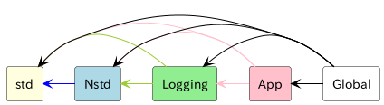

このように整理された依存関係は、 「パッケージとその構成ファイル」でも述べた通り、 大規模ソフトウェア開発においては特に重要であり、決して循環しないように維持しなければならない。

### Nstdライブラリを使用したリファクタリング

すでに述べた通り、「operator<<を使わない」で導入したコードは、Nstdで定義するべきである。 その場合、下記のようにさらに一般化するのが良いだろう。

```cpp
    //  example/template/nstd_0.h 4

    namespace Nstd {

    template <typename T>
    std::ostream& operator<<(std::ostream& os, std::vector<T> const& vec)
    {
        auto sep = "";

        for (auto const& i : vec) {
            os << std::exchange(sep, ", ") << i;
        }

        return os;
    }

    template <typename T>
    std::string ToString(std::vector<T> const& vec)
    {
        auto oss = std::ostringstream{};

        oss << vec;

        return oss.str();
    }
    }  // namespace Nstd
```

その単体テストは下記のようになる。

```cpp
    //  example/template/nstd_0_ut.cpp 13

    auto const ints = App::Ints_t{1, 2, 3};

    {
        auto oss = std::ostringstream{};

        using namespace Nstd;
        oss << ints << 4;
        ASSERT_EQ("1, 2, 34", oss.str());
    }
    {
        auto oss = std::ostringstream{};

        Nstd::operator<<(oss, ints) << 4;  // 念のためこの形式でもテスト
        ASSERT_EQ("1, 2, 34", oss.str());
    }

    ASSERT_EQ("1, 2, 3", Nstd::ToString(ints));
```

勘のいい読者なら、このコードをLOGGERから利用することで、 App:Ints_tのログ登録問題を解消できると思うかもしれない。 実際その通りなのであるが、そうした場合、 std::list等の他のコンテナや配列には対応できないという問題が残るため、 以降もしばらくNstdの開発を続ける。

### 安全なvector

std::vector、std::basic_string、std::array等の配列型コンテナは、

- operator[]経由でのメンバアクセスについて範囲の妥当性をチェックしない
- 範囲のチェックが必要ならばat()を使用する

という仕様になっているが、 ここではoperator[]にも範囲のチェックを行う配列型コンテナが必要になった場合について考える。

手始めにoperator[]にも範囲のチェックを行うstd::vector相当のコンテナSafeVectorを作ると、 下記のコードのようになる。

```cpp
    //  example/template/safe_vector_ut.cpp 10

namespace Nstd {

template <typename T>
struct SafeVector : std::vector<T> {
    using std::vector<T>::vector;  // 継承コンストラクタ

    using base_type = std::vector<T>;
    using size_type = typename base_type::size_type;

    typename base_type::reference       operator[](size_type i) { return this->at(i); }
    typename base_type::const_reference operator[](size_type i) const { return this->at(i); }
};
}  // namespace Nstd
```

このコードで行ったことは、

- std::vectorからSafeVectorをpublic継承する
- 継承コンストラクタの機能を使い、std::vectorのコンストラクタをSafeVectorで宣言する
- std::vector::atを使い、SafeVector::operator[]を定義する

である。単体テストは下記のようになる。

```cpp
    //  example/template/safe_vector_ut.cpp 30

    {
        auto v = Nstd::SafeVector<int>(10);  // ()での初期化

        ASSERT_EQ(10, v.size());
    }
    {
        auto const v = Nstd::SafeVector<int>{10};

        ASSERT_EQ(1, v.size());
        ASSERT_EQ(10, v[0]);
        ASSERT_THROW(v[1], std::out_of_range);  // エクセプションの発生
    }
    {
        auto v = Nstd::SafeVector<std::string>{"1", "2", "3"};

        ASSERT_EQ(3, v.size());
        ASSERT_EQ((std::vector<std::string>{"1", "2", "3"}), v);
        ASSERT_THROW(v[3], std::out_of_range);  // エクセプションの発生
    }
    {
        auto const v = Nstd::SafeVector<std::string>{"1", "2", "3"};

        ASSERT_EQ(3, v.size());
        ASSERT_EQ((std::vector<std::string>{"1", "2", "3"}), v);
        ASSERT_THROW(v[3], std::out_of_range);  // エクセプションの発生
    }
```

演習-std::arrayの継承

### 安全な配列型コンテナ

配列型コンテナはすでに述べたようにstd::vectorの他にすくなともstd::basic_string、 std::arrayがあるため、それらにも範囲チェックを導入する。

std::basic_stringはstd::vectorとほぼ同様に下記のようになる。

```cpp
    //  example/template/safe_vector_ut.cpp 62
    namespace Nstd {

    struct SafeString : std::string {
        using std::string::string;  // 継承コンストラクタ

        using base_type = std::string;
        using size_type = typename base_type::size_type;

        typename base_type::reference       operator[](size_type i) { return this->at(i); }
        typename base_type::const_reference operator[](size_type i) const { return this->at(i); }
    };
    }  // namespace Nstd
```

std::stringはstd::basic_string<char>のエイリアスであるため、 上記では、通常使われる形式であるstd::stringを継承したSafeStringを定義した。

この単体テストはSafeVectorの場合と同様に下記のようになる。

```cpp
    //  example/template/safe_vector_ut.cpp 80

    {
        auto s = Nstd::SafeString{"0123456789"};

        ASSERT_EQ(10, s.size());
        ASSERT_EQ("0123456789", s);
        ASSERT_THROW(s[10], std::out_of_range);
    }
    {
        auto const s = Nstd::SafeString(3, 'c');  // ()での初期化が必要

        ASSERT_EQ(3, s.size());
        ASSERT_EQ("ccc", s);
    }
```

std::arrayでは少々事情が異なるが、 std::vectorのコードパターンをそのまま適用すると下記のようになる。

```cpp
    //  example/template/safe_vector_ut.cpp 101

    namespace Nstd {

    template <typename T, size_t N>
    struct SafeArray : std::array<T, N> {
        using std::array<T, N>::array;  // 継承コンストラクタ

        using base_type = std::array<T, N>;
        using size_type = typename base_type::size_type;

        typename base_type::reference       operator[](size_type i) { return this->at(i); }
        typename base_type::const_reference operator[](size_type i) const { return this->at(i); }
    };
    }  // namespace Nstd
```

ただし、この実装には問題がある。

```cpp
    //  example/template/safe_vector_ut.cpp 122

    auto sa_not_init = Nstd::SafeArray<int, 3>{};

    ASSERT_EQ(3, sa_not_init.size());
    ASSERT_THROW(sa_not_init[3], std::out_of_range);
```

上記コードでは、その問題が露見することはないが、以下のコードはコンパイルできない。

```cpp
    //  example/template/safe_vector_ut.cpp 132

    // std::initializer_listを引数とするコンストラクタが未定義
    auto sa_init = Nstd::SafeArray<int, 3>{1, 2, 3};

    // デフォルトコンストラクタがないため、未初期化
    Nstd::SafeArray<int, 3> const sa_const;
```

std::arrayにはコンストラクタが明示的に定義されていないため、 std::arrayにはデフォルトで自動生成される

- デフォルトコンストラクタ
- copyコンストラクタ
- moveコンストラクタ

以外のコンストラクタがないことが原因である。 従って、SafeArray(std::initializer_list)が定義されず前述したようにコンパイルエラーとなる。

この問題に対処したのが以下のコードである。

```cpp
    //  example/template/safe_vector_ut.cpp 146

    namespace Nstd {

    template <typename T, size_t N>
    struct SafeArray : std::array<T, N> {
        using std::array<T, N>::array;  // 継承コンストラクタ
        using base_type = std::array<T, N>;

        template <typename... ARGS>  // コンストラクタを定義
        SafeArray(ARGS... args) : base_type{args...}
        {
        }

        using size_type = typename base_type::size_type;

        typename base_type::reference       operator[](size_type i) { return this->at(i); }
        typename base_type::const_reference operator[](size_type i) const { return this->at(i); }
    };
    }  // namespace Nstd
```

上記コードで注目すべきは、パラメータパックをテンプレートパラメータとしたコンストラクタである。 これにより、前例ではコンパイルすらできなかった下記のような初期化子リストを用いた単体テストが、 このコンストラクタによりパスするようになった。

```cpp
    //  example/template/safe_vector_ut.cpp 181
    {
        auto sa_init = Nstd::SafeArray<int, 3>{1, 2, 3};

        ASSERT_EQ(3, sa_init.size());
        ASSERT_EQ(1, sa_init[0]);
        ASSERT_EQ(2, sa_init[1]);
        ASSERT_EQ(3, sa_init[2]);
        ASSERT_THROW(sa_init[3], std::out_of_range);
    }
    {
        auto const sa_string_const = Nstd::SafeArray<std::string, 5>{"1", "2", "3"};

        ASSERT_EQ(5, sa_string_const.size());
        ASSERT_EQ("1", sa_string_const[0]);
        ASSERT_EQ("2", sa_string_const[1]);
        ASSERT_EQ("3", sa_string_const[2]);
        ASSERT_EQ("", sa_string_const[3]);
        ASSERT_EQ("", sa_string_const[4]);
        ASSERT_THROW(sa_string_const[5], std::out_of_range);
    }
```

この効果を生み出した上記を抜粋した下記のコードには解説が必要だろう。

```cpp
    //  example/template/safe_vector_ut.cpp 155

    template <typename... ARGS>  // コンストラクタを定義
    SafeArray(ARGS... args) : base_type{args...}
    {
    }
```

一般にコンストラクタには「メンバ変数の初期化」と「基底クラスの初期化」が求められるが、 SafeArrayにはメンバ変数が存在しないため、 このコンストラクタの役割は「基底クラスの初期化」のみとなる。 基底クラスstd::array(上記例ではbase_typeにエイリアスしている) には名前が非規定の配列メンバのみを持つため、 これを初期化するためには初期化子リスト (「初期化子リストコンストラクタ」、 「一様初期化」参照)を用いるのが良い。

ということは、SafeArrayの初期化子リストコンストラクタには、 「基底クラスstd::arrayに初期子リストを与えて初期化する」形式が必要になる。 値を持つパラメータパックは初期化子リストに展開できるため、 ここで必要な形式はパラメータパックとなる。 これを実現したのが上記に抜粋したわずか数行のコードである。

### 初期化子リストの副作用

上記SafeArrayの初期化子リストコンストラクタは以下のようなコードを許可しない。

```cpp
    //  example/template/safe_vector_ut.cpp 213
    {
        auto sa_init = Nstd::SafeArray<int, 3>{1.0, 2, 3};

        ASSERT_EQ(3, sa_init.size());
        ASSERT_EQ(1, sa_init[0]);
        ASSERT_EQ(2, sa_init[1]);
        ASSERT_EQ(3, sa_init[2]);
        ASSERT_THROW(sa_init[3], std::out_of_range);
    }
```

このコードをコンパイルすると、

```
    safe_vector_ut.cpp:147:41: error: narrowing conversion of ‘
                                        args#0’ from ‘double’ to ‘int’ -Werror=narrowing]
      147 |     SafeArray(ARGS... args) : base_type{args...}
          |                                         ^~~~
```

のようなエラーが出力されるが、

- double(上記例では1.0)をintに変換する際に縮小変換(narrowing conversio)nが起こる
- 初期化子リストでの縮小変換は許可されない

が原因である。これは意図しない縮小変換によるバグを防ぐ良い機能だと思うが、 ここではテンプレートメタプログラミングのテクニックを解説するため、 あえてこのコンパイルエラーを起こさないSafeArray2を開発する (言うまでもないが、通常のソフトウェア開発では、 縮小変換によるコンパイルエラーを回避するようなコードを書いてはならない)。

SafeArray2のコードは、

- STLのtype_traitsの使用
- テンプレートの特殊化
- メンバ関数テンプレートとオーバーロードによる静的ディスパッチ(コンパイル時ディスパッチ)
- SFINAE

等のメタ関数系のテクニックが必要になるため、 まずはこれらを含めたテンプレートのテクニックについて解説し、 その後SafeArray2を見ていくことにする。

## メタ関数のテクニック

本章で扱うメタ関数とは、型、定数、クラステンプレート等からなるテンプレート引数から、 型、エイリアス、定数等を宣言、定義するようなクラステンプレート、関数テンプレート、 定数テンプレート、エイリアステンプレートを指す (本章ではこれらをまとめて単にテンプレート呼ぶことがある)。

演習-エイリアステンプレート

### STLのtype_traits

メタ関数ライブラリの代表的実装例はSTLの [type_traits](https://cpprefjp.github.io/reference/type_traits.html)である。

ここでは、よく使ういくつかのtype_traitsテンプレートの使用例や解説を示す。

#### std::true_type/std::false_type

std::true_type/std::false_typeは真/偽を返すSTLメタ関数群の戻り型となる型エイリアスであるため、 最も使われるテンプレートの一つである。

これらは、下記で確かめられる通り、後述するstd::integral_constantを使い定義されている。

```cpp
    //  example/template_cpp17/type_traits_ut.cpp 13

    // std::is_same_vの2パラメータが同一であれば、std::is_same_v<> == true
    static_assert(std::is_same_v<std::integral_constant<bool, true>, std::true_type>);
    static_assert(std::is_same_v<std::integral_constant<bool, false>, std::false_type>);
```

それぞれの型が持つvalue定数は、下記のように定義されている。

```cpp
    //  example/template_cpp17/type_traits_ut.cpp 20

    static_assert(std::true_type::value, "must be true");
    static_assert(!std::false_type::value, "must be false");
```

これらが何の役に立つのか直ちに理解することは難しいが、 true/falseのメタ関数版と考えれば、追々理解できるだろう。

以下に簡単な使用例を示す。

```cpp
    //  example/template_cpp17/type_traits_ut.cpp 29

    // 引数の型がintに変換できるかどうかを判定する関数
    // decltypeの中でのみ使用されるため、定義は不要
    constexpr std::true_type  IsCovertibleToInt(int);  // intに変換できる型はこちら
    constexpr std::false_type IsCovertibleToInt(...);  // それ以外はこちら
```

上記の単体テストは下記のようになる。

```cpp
    //  example/template_cpp17/type_traits_ut.cpp 40

    static_assert(decltype(IsCovertibleToInt(1))::value);
    static_assert(decltype(IsCovertibleToInt(1u))::value);
    static_assert(!decltype(IsCovertibleToInt(""))::value);  // ポインタはintに変換不可

    struct ConvertibleToInt {
        operator int();
    };

    struct NotConvertibleToInt {};

    static_assert(decltype(IsCovertibleToInt(ConvertibleToInt{}))::value);
    static_assert(!decltype(IsCovertibleToInt(NotConvertibleToInt{}))::value);

    // なお、IsCovertibleToInt()やConvertibleToInt::operator int()は実際に呼び出されるわけでは
    // ないため、定義は必要なく宣言のみがあれば良い。
```

IsCovertibleToIntの呼び出しをdecltypeのオペランドにすることで、 std::true_typeかstd::false_typeを受け取ることができる。

#### std::integral_constant

std::integral_constantは 「テンプレートパラメータとして与えられた型とその定数から新たな型を定義する」 クラステンプレートである。

以下に簡単な使用例を示す。

```cpp
    //  example/template_cpp17/type_traits_ut.cpp 62

    using int3 = std::integral_constant<int, 3>;

    // std::is_same_vの2パラメータが同一であれば、std::is_same_v<> == true
    static_assert(std::is_same_v<int, int3::value_type>);
    static_assert(std::is_same_v<std::integral_constant<int, 3>, int3::type>);
    static_assert(int3::value == 3);

    using bool_true = std::integral_constant<bool, true>;

    static_assert(std::is_same_v<bool, bool_true::value_type>);
    static_assert(std::is_same_v<std::integral_constant<bool, true>, bool_true::type>);
    static_assert(bool_true::value == true);
```

また、すでに示したようにstd::true_type/std::false_typeを実装するためのクラステンプレートでもある。

#### std::is_same

すでに上記の例でも使用したが、std::is_sameは2つのテンプレートパラメータが

- 同じ型である場合、std::true_type
- 違う型である場合、std::false_type

から派生した型となる。

以下に簡単な使用例を示す。

```cpp
    //  example/template_cpp17/type_traits_ut.cpp 99

    static_assert(std::is_same<int, int>::value);
    static_assert(std::is_same<int, int32_t>::value);   // 64ビットg++/clang++
    static_assert(!std::is_same<int, int64_t>::value);  // 64ビットg++/clang++
    static_assert(std::is_same<std::string, std::basic_string<char>>::value);
    static_assert(std::is_same<typename std::vector<int>::reference, int&>::value);
```

また、 C++17で導入されたstd::is_same_vは、定数テンプレートを使用し、 下記のように定義されている。

```cpp
    //  example/template_cpp17/type_traits_ut.cpp 90

    template <typename T, typename U>
    constexpr bool is_same_v{std::is_same<T, U>::value};
```

```cpp
    //  example/template_cpp17/type_traits_ut.cpp 108

    static_assert(is_same_v<int, int>);
    static_assert(is_same_v<int, int32_t>);   // 64ビットg++/clang++
    static_assert(!is_same_v<int, int64_t>);  // 64ビットg++/clang++
    static_assert(is_same_v<std::string, std::basic_string<char>>);
    static_assert(is_same_v<typename std::vector<int>::reference, int&>);
```

このような簡潔な記述の一般形式は、

```
   T::value  -> T_v
   T::type   -> T_t
```

のように定義されている(このドキュメントのほとんど場所では、簡潔な形式を用いる)。

第1テンプレートパラメータが第2テンプレートパラメータの基底クラスかどうかを判断する std::is_base_ofを使うことで下記のようにstd::is_sameの基底クラス確認することもできる。

```cpp
    //  example/template_cpp17/type_traits_ut.cpp 117

    static_assert(std::is_base_of_v<std::true_type, std::is_same<int, int>>);
    static_assert(std::is_base_of_v<std::false_type, std::is_same<int, char>>);
```

#### std::enable_if

std::enable_ifは、bool値である第1テンプレートパラメータが

- trueである場合、型である第2テンプレートパラメータをメンバ型typeとして宣言する。
- falseである場合、メンバ型typeを持たない。

下記のコードはクラステンプレートの特殊化を用いたstd::enable_ifの実装例である。

```cpp
    //  example/template_cpp17/type_traits_ut.cpp 124

    template <bool T_F, typename T = void>
    struct enable_if;

    template <typename T>
    struct enable_if<true, T> {
        using type = T;
    };

    template <typename T>
    struct enable_if<false, T> {  // メンバエイリアスtypeを持たない
    };

    template <bool COND, typename T = void>
    using enable_if_t = typename enable_if<COND, T>::type;
```

std::enable_ifの使用例を下記に示す。

```cpp
    //  example/template_cpp17/type_traits_ut.cpp 148

    static_assert(std::is_same_v<void, std::enable_if_t<true>>);
    static_assert(std::is_same_v<int, std::enable_if_t<true, int>>);
```

実装例から明らかなように

- std::enable_if<true>::typeはwell-formed
- std::enable_if<false>::typeはill-formed

となるため、下記のコードはコンパイルできない。

```cpp
    //  example/template_cpp17/type_traits_ut.cpp 155

    // 下記はill-formedとなるため、コンパイルできない。
    static_assert(std::is_same_v<void, std::enable_if_t<false>>);
    static_assert(std::is_same_v<int, std::enable_if_t<false, int>>);
```

std::enable_ifのこの特性と後述するSFINAEにより、 様々な静的ディスパッチを行うことができる。

#### std::conditional

std::conditionalは、bool値である第1テンプレートパラメータが

- trueである場合、第2テンプレートパラメータ
- falseである場合、第3テンプレートパラメータ

をメンバ型typeとして宣言する。

下記のコードはクラステンプレートの特殊化を用いたstd::conditionalの実装例である。

```cpp
    //  example/template_cpp17/type_traits_ut.cpp 164

    template <bool T_F, typename, typename>
    struct conditional;

    template <typename T, typename U>
    struct conditional<true, T, U> {
        using type = T;
    };

    template <typename T, typename U>
    struct conditional<false, T, U> {
        using type = U;
    };

    template <bool COND, typename T, typename U>
    using conditional_t = typename conditional<COND, T, U>::type;
```

std::conditionalの使用例を下記に示す。

```cpp
    //  example/template_cpp17/type_traits_ut.cpp 189

    static_assert(std::is_same_v<int, std::conditional_t<true, int, char>>);
    static_assert(std::is_same_v<char, std::conditional_t<false, int, char>>);
```

#### std::is_void

std::is_voidはテンプレートパラメータの型が

- voidである場合、std::true_type
- voidでない場合、std::false_type

から派生した型となる。

以下に簡単な使用例を示す。

```cpp
    //  example/template_cpp17/type_traits_ut.cpp 82

    static_assert(std::is_void<void>::value);
    static_assert(!std::is_void<int>::value);
    static_assert(!std::is_void<std::string>::value);
```

### is_void_xxxの実装

ここではstd::is_voidに似た以下のような仕様を持ついくつかのテンプレートis_void_xxxの実装を考える。

| テンプレートパラメータ | 戻り値 |
| --- | --- |
| void | true |
| 非void | false |

それぞれのis_void_xxxは下記テーブルで示した言語機能を使用して実装する。

| is_void_xxx | 実装方法 |
| --- | --- |
| is_void_f | 関数テンプレートの特殊化 |
| is_void_s | クラステンプレートの特殊化 |
| is_void_sfinae_f | FINAEと関数テンプレートのオーバーロード |
| is_void_sfinae_s | FINAEとクラステンプレートの特殊化 |
| is_void_concept_s | コンセプトとクラステンプレートの特殊化 |
| is_void_ena_s | std::enable_ifによるSFINAEとクラステンプレートの特殊化 |
| is_void_cond_s | std::conditionalと関数テンプレートの特殊化 |

なお、実装例をシンプルに保つため、 理解の妨げとなり得る下記のような正確性(例外条件の対応)等のためのコードを最低限に留めた。

- テンプレートパラメータの型のチェック
- テンプレートパラメータの型からのポインタ/リファレンス/const/volatileの削除
- 戻り型からのconst/volatileの削除

これは、「テンプレートプログラミングでの有用なテクニックの解説」 というここでの目的を見失わないための措置である。

#### is_void_f

関数テンプレートの特殊化を使用したis_void_fの実装は以下のようになる。

```cpp
    //  example/template/is_void_ut.cpp 8

    template <typename T>
    constexpr bool is_void_f() noexcept
    {
        return false;
    }

    template <>
    constexpr bool is_void_f<void>() noexcept
    {
        return true;
    }

    template <typename T>
    constexpr bool is_void_f_v{is_void_f<T>()};
```

単純なので解説は不要だろう。これらの単体テストは下記のようになる。

```cpp
    //  example/template/is_void_ut.cpp 28

    static_assert(!is_void_f_v<int>);
    static_assert(!is_void_f_v<std::string>);
    static_assert(is_void_f_v<void>);
```

関数テンプレートの特殊化には、

- 特殊化された関数テンプレートとそのプライマリテンプレートのシグネチャ、 戻り値は一致しなければならない
- クラステンプレートのような部分特殊化は許可されない

のような制限があるため用途は限られるが、関数テンプレートはオーバーロードすることが可能である。

演習-SFINAEを利用しない関数テンプレートの特殊化によるis_void

#### is_void_s

クラステンプレートの特殊化を使用したis_void_sの実装は以下のようになる。

```cpp
    //  example/template/is_void_ut.cpp 36

    template <typename T>
    struct is_void_s {
        static constexpr bool value{false};
    };

    template <>
    struct is_void_s<void> {
        static constexpr bool value{true};
    };

    template <typename T>
    constexpr bool is_void_s_v{is_void_s<T>::value};
```

is_void_fと同様に単純なので解説は不要だろう。これらの単体テストは下記のようになる。

```cpp
    //  example/template/is_void_ut.cpp 54

    static_assert(!is_void_s_v<int>);
    static_assert(!is_void_s_v<std::string>);
    static_assert(is_void_s_v<void>);
```

演習-SFINAEを利用しないクラステンプレートの特殊化によるis_void

#### is_void_sfinae_f

SFINAEを使用した関数テンプレートis_void_sfinae_fの実装は以下のようになる。

```cpp
    //  example/template/is_void_ut.cpp 62

    namespace Inner_ {

    // T == void
    template <typename T>
    constexpr auto is_void_sfinae_f_detector(void const* v, T const* t) noexcept
        -> decltype(t = v, bool{})  // T != voidの場合、t = vはill-formed
                                    // T == voidの場合、well-formedでbool型生成
    {
        return true;
    }

    // T != void
    template <typename T>
    constexpr auto is_void_sfinae_f_detector(void const*, T const*) noexcept
        -> decltype(sizeof(T), bool{})  // T != voidの場合、well-formedでbool型生成
                                        // T == voidの場合、sizeof(T)はill-formed
    {
        return false;
    }
    }  // namespace Inner_

    template <typename T>
    constexpr bool is_void_sfinae_f() noexcept
    {
        return Inner_::is_void_sfinae_f_detector(nullptr, static_cast<T*>(nullptr));
    }

    template <typename T>
    constexpr bool is_void_sfinae_f_v{is_void_sfinae_f<T>()};
```

関数テンプレートである2つのis_void_sfinae_f_detectorのオーバーロードにSFINAEを使用している。

1つ目のis_void_sfinae_f_detectorでは、

| T | t = v の診断(コンパイル) |
| --- | --- |
| == void | well-formed |
| != void | ill-formed |

であるため、Tがvoidの時のみname lookupの対象になる。

2つ目のis_void_sfinae_f_detectorでは、

| T | sizeof(T)の診断(コンパイル) |
| --- | --- |
| == void | ill-formed |
| != void | well-formed |

であるため、Tが非voidの時のみname lookupの対象になる。

is_void_sfinae_fはこの性質を利用し、

- T == voidの場合、1つ目のis_void_sfinae_f_detectorが選択され、戻り値はtrue
- T != voidの場合、2つ目のis_void_sfinae_f_detectorが選択され、戻り値はfalse

となる。念のため単体テストを示すと下記のようになる。

```cpp
    //  example/template/is_void_ut.cpp 97

    static_assert(!is_void_sfinae_f_v<int>);
    static_assert(!is_void_sfinae_f_v<std::string>);
    static_assert(is_void_sfinae_f_v<void>);
```

一般にファイル外部に公開するテンプレートは、 コンパイルの都合上ヘッダファイルにその全実装を記述することになる。 これは、本来外部公開すべきでない実装の詳細である is_void_sfinae_f_detectorのようなテンプレートに関しては大変都合が悪い。 というのは、外部から使用されたくない実装の詳細が使われてしまうことがあり得るからである。 上記の例では、こういうことに備え 「これは外部非公開である」ということを示す名前空間Inner_ (「名前空間」参照) を導入した。

関数テンプレートはクラステンプレート内にも定義することができるため、 is_void_sfinae_fは下記のように実装することも可能である。この場合、名前空間Inner_は不要になる。

```cpp
    //  example/template/is_void_ut.cpp 106

    template <typename T>
    class is_void_sfinae_f {
        // U == void
        template <typename U>
        static constexpr auto detector(void const* v, U const* u) noexcept
            -> decltype(u = v, bool{})  // U != voidの場合、t = vはill-formed
                                        // U == voidの場合、well-formedでbool型生成
        {
            return true;
        }

        // U != void
        template <typename U>
        static constexpr auto detector(void const*, U const*) noexcept
            -> decltype(sizeof(U), bool{})  // U != voidの場合、well-formedでbool型生成
                                            // U == voidの場合、ill-formed
        {
            return false;
        }

    public:
        static constexpr bool value{is_void_sfinae_f::detector(nullptr, static_cast<T*>(nullptr))};
    };

    template <typename T>
    constexpr bool is_void_sfinae_f_v{is_void_sfinae_f<T>::value};
```

```cpp
    //  example/template/is_void_ut.cpp 138

    static_assert(!is_void_sfinae_f_v<int>);
    static_assert(!is_void_sfinae_f_v<std::string>);
    static_assert(is_void_sfinae_f_v<void>);
```

演習-SFINAEを利用した関数テンプレートの特殊化によるis_void

#### is_void_sfinae_s

SFINAEを使用したクラステンプレートis_void_sfinae_sの実装は以下のようになる。

```cpp
    //  example/template/is_void_ut.cpp 147

    namespace Inner_ {
    template <typename T>
    T*& t2ptr();  // 定義は不要
    }  // namespace Inner_

    template <typename T, typename = void*&>
    struct is_void_sfinae_s : std::false_type {
    };

    template <typename T>
    struct is_void_sfinae_s<
        T,
        // T != voidの場合、ill-formed
        // T == voidの場合、well-formedでvoid*&生成
        decltype(Inner_::t2ptr<T>() = Inner_::t2ptr<void>())

        > : std::true_type {
    };

    template <typename T>
    constexpr bool is_void_sfinae_s_v{is_void_sfinae_s<T>::value};
```

1つ目のis_void_sfinae_sはプライマリテンプレートである。 is_void_sfinae_sの特殊化がname lookupの対象の中に見つからなかった場合、 これが使われる。

2つ目のis_void_sfinae_sは、上記を抜粋した下記のコード

```cpp
    //  example/template/is_void_ut.cpp 163

    // T != voidの場合、ill-formed
    // T == voidの場合、well-formedでvoid*&生成
    decltype(Inner_::t2ptr<T>() = Inner_::t2ptr<void>())
```

がT == voidの時のみ、well-formedになり、このテンプレートは下記のようにインスタンス化される。

```cpp
    struct is_void_sfinae_s<void, void*&>
```

この形状はプライマリテンプレートの

- 第1パラメータにvoidを与える
- 第2パラメータには何も与えない(デフォルトのまま)

とした場合の、つまりプライマリテンプレートを

```cpp
    struct is_void_sfinae_s<void>   // プライマリテンプレート
```

としてインスタンス化した場合と一致する。 プライマリと特殊化が一致した場合、特殊化されたものがname lookupで選択される。

T != voidの場合、 2つ目のis_void_sfinae_sはill-formedになり、name lookupの対象から外れるため、 プライマリが選択される。

以上をまとめると、

| T | is_void_sfinae_sの基底クラス |
| --- | --- |
| == void | std::true_type |
| != void | std::false_type |

となる。以下の単体テストによって、このことを確かめることができる。

```cpp
    //  example/template/is_void_ut.cpp 180

    static_assert(!is_void_sfinae_s_v<int>);
    static_assert(std::is_base_of_v<std::false_type, is_void_sfinae_s<int>>);

    static_assert(!is_void_sfinae_s_v<std::string>);
    static_assert(std::is_base_of_v<std::false_type, is_void_sfinae_s<std::string>>);

    static_assert(is_void_sfinae_s_v<void>);
    static_assert(std::is_base_of_v<std::true_type, is_void_sfinae_s<void>>);
```

上記コードのように「プライマリテンプレートのデフォルトパラメータ」と、

```cpp
    //  example/template/is_void_ut.cpp 163

    // T != voidの場合、ill-formed
    // T == voidの場合、well-formedでvoid*&生成
    decltype(Inner_::t2ptr<T>() = Inner_::t2ptr<void>())
```

が「well-formedであった場合に生成される型」が一致することを利用した静的ディスパッチは、 SFINAEとクラステンプレートの特殊化を組み合わせたメタ関数の典型的な実装パターンである。 ただし、一般にはill-formedを起こすためにst::enable_ifを使うことが多いため、 「is_void_ena_sの実装」でその例を示す。

演習-SFINAEを利用したクラステンプレートの特殊化によるis_void

#### is_void_concept_s

is_void_sfinae_sの実装で使用したSFINAEを回避し、 コンセプトを使用することで可読性の向上が見込める。 以下の実装で使用したsame_asは<concepts>で定義されているコンセプトと同様のものである。

```cpp
    //  example/template/is_void_ut.cpp 193

    template <typename T>
    struct is_void_concept_s : std::false_type {
    };

    template <typename T>
    requires std::same_as<T, void>  // コンセプトによるTの制約
    struct is_void_concept_s<T> : std::true_type {
    };
```

```cpp
    //  example/template/is_void_ut.cpp 207

    static_assert(!is_void_concept_s<int>::value);
    static_assert(std::is_base_of_v<std::false_type, is_void_concept_s<int>>);

    static_assert(!is_void_concept_s<std::string>::value);
    static_assert(std::is_base_of_v<std::false_type, is_void_concept_s<std::string>>);

    static_assert(is_void_concept_s<void>::value);
    static_assert(std::is_base_of_v<std::true_type, is_void_concept_s<void>>);
```

下記に示した通り、テンプレート特殊化はクラスのみなく定数に対しても使用することができる。

```cpp
    //  example/template/is_void_ut.cpp 220

    template <typename T>
    constexpr bool is_void_concept_s_v = false;

    template <typename T>
    requires std::same_as<T, void>
    constexpr bool is_void_concept_s_v<T> = true;
```

以下に示した通り、is_void_sfinae_sの実装で示した定数テンプレートのテストと同様になっている。

```cpp
    //  example/template/is_void_ut.cpp 232

    static_assert(!is_void_concept_s_v<int>);
    static_assert(!is_void_concept_s_v<std::string>);
    static_assert(is_void_concept_s_v<void>);
```

#### is_void_ena_s

std::enable_ifによるSFINAEとクラステンプレートの特殊化を使用した is_void_ena_sの実装は以下のようになる。

```cpp
    //  example/template/is_void_ut.cpp 240
    template <typename T, typename = void>
    struct is_void_ena_s : std::false_type {
    };

    template <typename T>
    struct is_void_ena_s<
        T,
        typename std::enable_if_t<is_void_f<T>()>
        > : std::true_type {
    };

    template <typename T>
    constexpr bool is_void_ena_s_v{is_void_ena_s<T>::value};
```

この例では、「is_void_sfinae_sの実装」の

```cpp
    //  example/template/is_void_ut.cpp 163

    // T != voidの場合、ill-formed
    // T == voidの場合、well-formedでvoid*&生成
    decltype(Inner_::t2ptr<T>() = Inner_::t2ptr<void>())
```

で示したSFINAEの処理を上記を抜粋した下記のコード

```cpp
    //  example/template/is_void_ut.cpp 250

    typename std::enable_if_t<is_void_f<T>()>
```

で行っている。 std::enable_ifの値パラメータis_void_f<T>()は、「is_void_fの実装」で示したものである。

単体テストは、「is_void_sfinae_sの実装」で示したものとほぼ同様で、以下のようになる。

```cpp
    //  example/template/is_void_ut.cpp 264

    static_assert(!is_void_ena_s_v<int>);
    static_assert(std::is_base_of_v<std::false_type, is_void_ena_s<int>>);

    static_assert(!is_void_ena_s_v<std::string>);
    static_assert(std::is_base_of_v<std::false_type, is_void_ena_s<std::string>>);

    static_assert(is_void_ena_s_v<void>);
    static_assert(std::is_base_of_v<std::true_type, is_void_ena_s<void>>);
```

#### is_void_cond_s

std::conditionalと関数テンプレートの特殊化を使用したis_void_cond_sの実装は以下のようになる。

```cpp
    //  example/template/is_void_ut.cpp 277
    template <typename T>
    struct is_void_cond_s : std::conditional_t<is_void_f<T>(), std::true_type, std::false_type> {
    };

    template <typename T>
    constexpr bool is_void_cond_s_v{is_void_cond_s<T>::value};
```

std::conditionalの値パラメータis_void_f<T>()は、「is_void_fの実装」で示したものである。 この例では、SFINAEもクラステンプレートの特殊化も使用していないが、 下記単体テストからわかる通り、「is_void_sfinae_sの実装」と同じ機能を備えている。

```cpp
    //  example/template/is_void_ut.cpp 288

    static_assert(!is_void_cond_s_v<int>);
    static_assert(std::is_base_of_v<std::false_type, is_void_cond_s<int>>);

    static_assert(!is_void_cond_s_v<std::string>);
    static_assert(std::is_base_of_v<std::false_type, is_void_cond_s<std::string>>);

    static_assert(is_void_cond_s_v<void>);
    static_assert(std::is_base_of_v<std::true_type, is_void_cond_s<void>>);
```

### is_same_xxxの実装

ここではstd::is_same<T, U>に似た、 以下のような仕様を持ついくつかのテンプレートis_same_xxxの実装を考える。

| テンプレートパラメータ | 戻り値 |
| --- | --- |
| T == U | true |
| T != U | false |

それぞれのis_same_xxxは下記テーブルで示された言語機能を使用して実装する。

| is_same_xxx | 実装方法 |
| --- | --- |
| is_same_f | 関数テンプレートのオーバーロード |
| is_same_v | 定数テンプレートの特殊化 |
| is_same_s | クラステンプレートの特殊化 |
| is_same_sfinae_f | SFINAEと関数テンプレート/関数のオーバーロード |
| is_same_sfinae_s | SFINAEとクラステンプレートの特殊化 |
| same_as | コンセプトよるis_same_sfinae_sと同一の機能 |
| is_same_templ | テンプレートテンプレートパラメータ |
| IsSameSomeOf | パラメータパックと再帰 |
| OneOf | IsSameSomeOfをコンセプトに |

#### is_same_f

関数テンプレートのオーバーロードを用いたis_same_fの実装は以下のようになる。

```cpp
    //  example/template_cpp17/is_same_ut.cpp 9

    template <typename T, typename U>
    constexpr bool is_same_f_helper(T const*, U const*) noexcept
    {
        return false;
    }

    template <typename T>
    constexpr bool is_same_f_helper(T const*, T const*) noexcept
    {
        return true;
    }

    template <typename T, typename U>
    constexpr bool is_same_f() noexcept
    {
        return is_same_f_helper(static_cast<T*>(nullptr), static_cast<U*>(nullptr));
    }

    template <typename T, typename U>
    constexpr bool is_same_f_v{is_same_f<T, U>()};
```

すでに述べたように関数テンプレートの部分特殊化は言語仕様として認められておらず、

```cpp
    //  example/template_cpp17/is_same_ut.cpp 34

    template <typename T, typename U>
    constexpr bool is_same_f()
    {
        return true;
    }

    template <typename T>
    constexpr bool is_same_f<T, T>()
    {
        return true;
    }
```

上記のようなのようなコードは、以下のようなコンパイルエラーになる (g++/clang++のような優れたコンパイラを使えば、 以下のメッセージのように簡単に問題点が理解できることもある)。

```
    is_same_ut.cpp:35:32: error: non-class, non-variable partial specialization ‘
                                          is_same_f<T, T>’ is not allowed
        35 | constexpr bool is_same_f<T, T>()
```

関数テンプレートは部分特殊化が出来ない代わりに、 同じ識別子を持つ関数や関数テンプレートとのオーバーロードができる。関数とのオーバーロードの場合、 is_same_f_helper<T>()のようなテンプレートパラメータを直接使用した静的ディスパッチが出来ないため、 常に型推測によるディスパッチが必要になる。

単体テストは以下のようになる。

```cpp
    //  example/template_cpp17/is_same_ut.cpp 52

    static_assert(!is_same_f_v<int, void>);
    static_assert(is_same_f_v<int, int>);
    static_assert(!is_same_f_v<int, uint32_t>);
    static_assert(is_same_f_v<std::string, std::basic_string<char>>);
```

#### is_same_v

定数テンプレートの特殊化を用いたis_same_vの実装は以下のようになる。

```cpp
    //  example/template_cpp17/is_same_ut.cpp 61

    template <typename T, typename U>
    constexpr bool is_same_v{false};

    template <typename T>
    constexpr bool is_same_v<T, T>{true};
```

単純であるため、解説は不要だろう。 単体テストは以下のようになる。

```cpp
    //  example/template_cpp17/is_same_ut.cpp 72

    static_assert(!is_same_v<int, void>);
    static_assert(is_same_v<int, int>);
    static_assert(!is_same_v<int, uint32_t>);
    static_assert(is_same_v<std::string, std::basic_string<char>>);
```

#### is_same_s

クラステンプレートの特殊化を用いたis_same_sの実装は以下のようになる。

```cpp
    //  example/template_cpp17/is_same_ut.cpp 81

    template <class T, class U>
    struct is_same_s : std::false_type {
    };

    template <class T>
    struct is_same_s<T, T> : std::true_type {
    };

    template <typename T, typename U>
    constexpr bool is_same_s_v{is_same_s<T, U>::value};
```

「is_same_vの実装」と同様に単純であるため、解説は不要だろう。 単体テストは以下のようになる。

```cpp
    //  example/template_cpp17/is_same_ut.cpp 97

    static_assert(!is_same_s_v<int, void>);
    static_assert(is_same_s_v<int, int>);
    static_assert(!is_same_s_v<int, uint32_t>);
    static_assert(is_same_s_v<std::string, std::basic_string<char>>);
```

#### is_same_sfinae_f

SFINAEと関数テンプレート/関数のオーバーロードを用いたis_same_sfinae_f実装は以下のようになる。

```cpp
    //  example/template_cpp17/is_same_ut.cpp 106

    namespace Inner_ {
    template <typename T, typename U>
    constexpr auto is_same_sfinae_f_detector(T const* t, U const* u) noexcept
        -> decltype(t = u, u = t, bool{})  // T != Uの場合、t = u, u = tはill-formed
                                           // T == Uの場合、well-formedでbool型生成
    {
        return true;
    }

    constexpr bool is_same_sfinae_f_detector(...) noexcept { return false; }
    }  // namespace Inner_

    template <typename T, typename U>
    constexpr bool is_same_sfinae_f() noexcept
    {
        return Inner_::is_same_sfinae_f_detector(static_cast<T*>(nullptr), static_cast<U*>(nullptr));
    }

    template <typename T, typename U>
    constexpr bool is_same_sfinae_f_v{is_same_sfinae_f<T, U>()};
```

上記の抜粋である下記コードのコメントで示したように、

```cpp
    //  example/template_cpp17/is_same_ut.cpp 112

    -> decltype(t = u, u = t, bool{})  // T != Uの場合、t = u, u = tはill-formed
                                       // T == Uの場合、well-formedでbool型生成
```

T != Uの場合、この関数テンプレートはill-formedとなりname lookupの対象ではなくなる。 その結果、関数is_same_sfinae_f_detectorが選択される。 省略記号”…“(ellipsis)を引数とする関数は、そのオーバーロード群の中での最後の選択となるため、 T == Uの場合は、関数テンプレートis_same_sfinae_f_detectorが選択される。

単体テストは以下のようになる。

```cpp
    //  example/template_cpp17/is_same_ut.cpp 136

    static_assert(!is_same_sfinae_f_v<int, void>);
    static_assert(is_same_sfinae_f_v<int, int>);
    static_assert(!is_same_sfinae_f_v<int, uint32_t>);
    static_assert(is_same_sfinae_f_v<std::string, std::basic_string<char>>);
```

#### is_same_sfinae_s

SFINAEとクラステンプレートの特殊化を用いたis_same_sfinae_sの実装は以下のようになる。

```cpp
    //  example/template_cpp17/is_same_ut.cpp 144

    namespace Inner_ {
    template <typename T>
    T*& t2ptr();
    }

    template <typename T, typename U, typename = T*&>
    struct is_same_sfinae_s : std::false_type {
    };

    template <typename T, typename U>
    struct is_same_sfinae_s<
        T, U,

        // T != Uの場合、ill-formed
        // T == Uの場合、well-formedでT*&生成
        decltype(Inner_::t2ptr<T>() = Inner_::t2ptr<U>(), Inner_::t2ptr<U>() = Inner_::t2ptr<T>())
        > : std::true_type {
    };

    template <typename T, typename U>
    constexpr bool is_same_sfinae_s_v{is_same_sfinae_s<T, U>::value};
```

「is_void_sfinae_sの実装」とほぼ同様であるため、解説は不要だろう。 単体テストは以下のようになる。

```cpp
    //  example/template_cpp17/is_same_ut.cpp 172

    static_assert(!is_same_sfinae_s_v<int, void>);
    static_assert(is_same_sfinae_s_v<int, int>);
    static_assert(!is_same_sfinae_s_v<int, uint32_t>);
    static_assert(is_same_sfinae_s_v<std::string, std::basic_string<char>>);
```

#### same_as

SFINAEによるis_same_sfinae_sの難解なコードをコンセプト よりリファクタリングしたコードを以下に示す。

```cpp
    //  example/template_cpp17/is_same_ut.cpp 181

    #if __cplusplus >= 202002L  // c++20
    template <typename T, typename U>
    concept same_as = requires(T const* t, U const* u)
    {
        {t = u, u = t};
    };

    #else  // c++17
    template <typename T, typename U>
    inline constexpr bool same_as = is_same_sfinae_s_v<T, U>;

    #endif
```

is_same_sfinae_sは定数テンプレートであり、same_asはコンセプトであるが、 下記のテストから明らかな通り、ほぼ同様に同様に使用することができる。

```cpp
    //  example/template_cpp17/is_same_ut.cpp 196

    static_assert(!same_as<int, void>);
    static_assert(same_as<int, int>);
    static_assert(!same_as<int, uint32_t>);
    static_assert(same_as<std::string, std::basic_string<char>>);
```

「is_same_s」で紹介した特殊化のテクニックを下記のように使用することができる。

```cpp
    //  example/template_cpp17/is_same_ut.cpp 203

    #if __cplusplus >= 202002L  // c++20
    template <typename T, typename U>
    struct is_same_concept_s : std::false_type {
    };

    template <typename T, typename U>
    requires same_as<T, U>
    struct is_same_concept_s<T, U> : std::true_type {
    };

    #else  // c++17
    template <typename T, typename U, typename = void>
    struct is_same_concept_s : std::false_type {
    };

    template <typename T, typename U>
    struct is_same_concept_s<T, U, std::enable_if_t<same_as<T, U>, void>> : std::true_type {
    };

    #endif

    static_assert(!is_same_concept_s<int, void>::value);
    static_assert(is_same_concept_s<int, int>::value);
    static_assert(!is_same_concept_s<int, uint32_t>::value);
    static_assert(is_same_concept_s<std::string, std::basic_string<char>>::value);
```

#### is_same_templ

例えば、std::stringとstd::basic_string<T>が同じもしくは違う型であることを確認するためには、 すでに示したis_same_sを使用し、

```cpp
    //  example/template_cpp17/is_same_ut.cpp 246

    static_assert(is_same_s_v<std::string, std::basic_string<char>>);
    static_assert(!is_same_s_v<std::string, std::basic_string<signed char>>);
```

のようにすればよいが、 以下に示したコードのようにテンプレートテンプレートパラメータを使うことでも実装できる。

```cpp
    //  example/template_cpp17/is_same_ut.cpp 234

    template <typename T, template <class...> class TEMPL, typename... ARGS>
    struct is_same_templ : is_same_sfinae_s<T, TEMPL<ARGS...>> {
    };

    template <typename T, template <class...> class TEMPL, typename... ARGS>
    constexpr bool is_same_templ_v{is_same_templ<T, TEMPL, ARGS...>::value};
```

上記のis_same_templは、第2引数にクラステンプレート、 第3引数以降にそのクラステンプレートの1個以上の引数を取ることができる。 使用例を兼ねた単体テストは以下のようになる。

```cpp
    //  example/template_cpp17/is_same_ut.cpp 251

    static_assert(is_same_templ_v<std::string, std::basic_string, char>);
    static_assert(!is_same_templ_v<std::string, std::basic_string, signed char>);
```

これを応用したエイリアステンプレート

```cpp
    //  example/template_cpp17/is_same_ut.cpp 258

    template <typename T>
    using gen_std_string = is_same_templ<std::string, std::basic_string, T>;

    template <typename T>
    constexpr bool gen_std_string_v{gen_std_string<T>::value};
```

は与えられたテンプレートパラメータがstd::stringを生成するかどうかを判定することができる。

```cpp
    //  example/template_cpp17/is_same_ut.cpp 269

    static_assert(gen_std_string_v<char>);
    static_assert(!gen_std_string_v<signed char>);
```

演習-テンプレートテンプレートパラメータ

#### IsSameSomeOf

IsSameSomeOfはこれまでの例とは少々異なり、

- 第1パラメータが第2パラメータ以降で指定された型のどれかと一致する SameAsSomeOfという名前のコンセプトを畳み込み式を使用し定義する
- SameAsSomeOfで制約したテンプレートパラメータをstd::bool_constantからIsSameSomeOfを派生させる

のような特徴のを持つ。 このようなIsSameSomeOfの実装はは以下のようになる。

```cpp
    //  example/h/nstd_type_traits.h 13

    namespace Nstd {
    namespace Inner_ {
    template <typename T, typename U, typename... Us>
    struct is_same_as_some_of_impl {  // 型特性の補助クラス: 複数の型と比較する再帰的な実装
        static constexpr bool value = std::is_same<T, U>::value || is_same_as_some_of_impl<T, Us...>::value;
    };

    // 再帰の終端条件: 比較する型が1つの場合
    template <typename T, typename U>
    struct is_same_as_some_of_impl<T, U> {
        static constexpr bool value = std::is_same<T, U>::value;
    };
    }  // namespace Inner_

    #if __cplusplus >= 202002L  // c++20
    // コンセプト: 複数の型のいずれかがTと同じかどうかをチェック
    template <typename T, typename U, typename... Us>
    concept SameAsSomeOf = (std::same_as<T, U> || (std::same_as<T, Us> || ...));

    #else  // c++17
    // コンセプトが使えない場合、上と同じ機能を持つ変数テンプレート
    template <typename T, typename U, typename... Us>
    constexpr bool SameAsSomeOf = Inner_::is_same_as_some_of_impl<T, U, Us...>::value;
    #endif

    // 型特性: TがUsのいずれかと同じ場合true_type、そうでない場合false_typeを継承
    template <typename T, typename U, typename... Us>
    struct IsSameSomeOf : std::bool_constant<SameAsSomeOf<T, U, Us...>> {
    };

    // 便利な定数テンプレート
    template <typename T, typename U, typename... Us>
    constexpr bool IsSameSomeOfV = IsSameSomeOf<T, U, Us...>::value;
    }  // namespace Nstd
```

IsSameSomeOfは、TがUsのいずれかと一致するかどうかのほとんどの処理をSameAsSomeOfに移譲する。

Usが1つだった場合、SameAsSomeOfは処理をstd::same_as(「same_as」参照)に委譲する。 Usが複数だった場合、畳み込み式を使用し上記の処理をその数分、繰り返す。

単体テストは以下のようになる。

```cpp
    //  example/template_cpp17/nstd_type_traits_ut.cpp 14

    static_assert(!Nstd::IsSameSomeOfV<int, int8_t, int16_t, uint16_t>);
    static_assert(Nstd::IsSameSomeOfV<int, int8_t, int16_t, uint16_t, int32_t>);
    static_assert(Nstd::IsSameSomeOfV<int&, int8_t, int16_t, int32_t&, int32_t>);
    static_assert(!Nstd::IsSameSomeOfV<int&, int8_t, int16_t, uint32_t&, int32_t>);
    static_assert(Nstd::IsSameSomeOfV<std::string, int, char*, std::string>);
    static_assert(!Nstd::IsSameSomeOfV<std::string, int, char*>);
```

演習-テンプレートパラメータを可変長にしたstd::is_same

#### OneOf

OneOfは、IsSameSomeOf同様の機能を持つコンセプトである。 OneOfの実装にはシンプルに記述するための畳み込み式を使用した。

```cpp
    //  h/nstd_concepts.h 52

    template <typename T, typename... Us>
    concept OneOf = (std::same_as<T, Us> || ...);
```

単体テストは以下のようになる。

```cpp
    //  example/template_cpp17/nstd_type_traits_ut.cpp 29

    static_assert(!Nstd::OneOf<int, int8_t, int16_t, uint16_t>);
    static_assert(Nstd::OneOf<int, int8_t, int16_t, uint16_t, int32_t>);
    static_assert(Nstd::OneOf<int&, int8_t, int16_t, int32_t&, int32_t>);
    static_assert(!Nstd::OneOf<int&, int8_t, int16_t, uint32_t&, int32_t>);
    static_assert(Nstd::OneOf<std::string, int, char*, std::string>);
    static_assert(!Nstd::OneOf<std::string, int, char*>);
```

### AreConvertibleXxxの実装

std::is_convertible<FROM, TO>は、

- 型FROMが型TOに変換できる場合、std::true_typeから派生する
- 型FROMが型TOに変換できない場合、std::false_typeから派生する

のような仕様を持つテンプレートである。

ここでは、

- std::is_convertibleを複数のFROMが指定できるように拡張したNstd::AreConvertible
- 縮小無しでの型変換ができるかどうかを判定するAreConvertibleWithoutNarrowConv

の実装を考える。

| AreConvertibleXxx | 実装方法 |
| --- | --- |
| AreConvertible | クラステンプレートの特殊化 |
| ConvertibleToAll | AreConvertibleをコンセプトへ |
| AreConvertibleWithoutNarrowConv | SFINAEとクラステンプレートの特殊化 |
| ConvertibleWithoutNarrowing | AreConvertibleWithoutNarrowConvをコンセプトへ |

#### AreConvertible

AreConvertibleの実装は以下のようになる。

```cpp
    //  example/h/nstd_type_traits.h 53

    namespace Nstd {
    namespace Inner_ {

    template <typename TO, typename FROM, typename... FROMs>
    struct are_convertible {
        static constexpr bool value{std::is_convertible_v<FROM, TO> && are_convertible<TO, FROMs...>::value};
    };

    template <typename TO, typename FROM>
    struct are_convertible<TO, FROM> {
        static constexpr bool value{std::is_convertible_v<FROM, TO>};
    };

    template <typename TO, typename... FROMs>
    constexpr bool are_convertible_v{are_convertible<TO, FROMs...>::value};
    }  // namespace Inner_

    template <typename TO, typename... FROMs>
    struct AreConvertible : std::conditional_t<Inner_::are_convertible_v<TO, FROMs...>, std::true_type, std::false_type> {
    };

    template <typename TO, typename... FROMs>
    constexpr bool AreConvertibleV{AreConvertible<TO, FROMs...>::value};
    }  // namespace Nstd
```

「IsSameSomeOfの実装」のコードパターンとほぼ同様であるため、解説は不要だろうが、

- パラメータパックの都合上、TOとFROMのパラメータの位置がstd::is_convertibleとは逆になる
- IsSameSomeOfでは条件の一つがtrueであればIsSameSomeOf::valueがtrueとなるが、 AreConvertibleでは全条件がtrueとならない限り、AreConvertible::valueがtrueとならない

ので注意が必要である。

単体テストは以下のようになる。

```cpp
    //  example/template_cpp17/nstd_type_traits_ut.cpp 43

    static_assert(Nstd::AreConvertibleV<int, int8_t, int16_t, int>);
    static_assert(Nstd::AreConvertibleV<int, char, int, int>);
    static_assert(!Nstd::AreConvertibleV<int, char*, int, int>);
    static_assert(Nstd::AreConvertibleV<std::string, std::string, char*, char[3]>);
    static_assert(!Nstd::AreConvertibleV<std::string, std::string, char*, int>);
```

#### AreConvertibleWithoutNarrowConv

縮小無しの型変換ができるかどうかを判定するAreConvertibleWithoutNarrowConvは、 AreConvertibleと同じように実装できるが、 その場合、AreConvertibleに対してstd::is_convertibleが必要になったように、 AreConvertibleWithoutNarrowConvに対しis_convertible_without_narrow_convが必要になる。

縮小無しでFROMからTOへの型変換ができるかどうかを判定するis_convertible_without_narrow_convは、 SFINAEと関数テンプレート/関数のオーバーライドを使用し以下のように実装できる。

```cpp
    //  example/h/nstd_type_traits.h 85

    namespace Nstd {
    namespace Inner_ {

    template <typename TO, typename FROM>
    class is_convertible_without_narrow_conv {
        template <typename T = TO, typename U = FROM>
        static constexpr auto detector(T* t, U* u) noexcept
            // 縮小無しでFROMからTOへ変換可能な場合、*t = T{*u}はwell-formed
            // 上記ではない場合、*t = T{*u}はill-formed
            -> decltype(*t = T{*u}, bool{})
        {
            return true;
        }

        static constexpr bool detector(...) noexcept { return false; }

    public:
        static constexpr bool value{
            is_convertible_without_narrow_conv::detector(static_cast<TO*>(nullptr), static_cast<FROM*>(nullptr))};
    };

    template <typename TO, typename FROM>
    constexpr bool is_convertible_without_narrow_conv_v{is_convertible_without_narrow_conv<TO, FROM>::value};
    }  // namespace Inner_
    }  // namespace Nstd
```

AreConvertibleWithoutNarrowConvはNstdで定義するため、その内部のみで用いる is_convertible_without_narrow_convはNstd::Inner_で定義している。

上記を抜粋した下記のコードは「縮小型変換を発生さる{}による初期化はill-formedになる」 ことをSFINAEに利用している。

```cpp
    //  example/h/nstd_type_traits.h 95

    // 縮小無しでFROMからTOへ変換可能な場合、*t = T{*u}はwell-formed
    // 上記ではない場合、*t = T{*u}はill-formed
    -> decltype(*t = T{*u}, bool{})
```

単体テストは以下のようになる。

```cpp
    //  example/template_cpp17/nstd_type_traits_ut.cpp 55

    static_assert(Nstd::Inner_::is_convertible_without_narrow_conv_v<int, int>);
    static_assert(Nstd::Inner_::is_convertible_without_narrow_conv_v<int, int16_t>);
    static_assert(!Nstd::Inner_::is_convertible_without_narrow_conv_v<int16_t, int>);
    static_assert(Nstd::Inner_::is_convertible_without_narrow_conv_v<std::string, char*>);
    static_assert(!Nstd::Inner_::is_convertible_without_narrow_conv_v<char*, std::string>);
```

is_convertible_without_narrow_convを利用したAreConvertibleWithoutNarrowConv の実装は以下のようになる。

```cpp
    //  example/h/nstd_type_traits.h 117

    namespace Nstd {
    namespace Inner_ {

    template <typename TO, typename FROM, typename... FROMs>
    struct are_convertible_without_narrow_conv {
        static constexpr bool value{
            is_convertible_without_narrow_conv_v<TO, FROM>
                  && are_convertible_without_narrow_conv<TO, FROMs...>::value};
    };

    template <typename TO, typename FROM>
    struct are_convertible_without_narrow_conv<TO, FROM> {
        static constexpr bool value{is_convertible_without_narrow_conv_v<TO, FROM>};
    };

    template <typename TO, typename FROM, typename... FROMs>
    constexpr bool are_convertible_without_narrow_conv_v{are_convertible_without_narrow_conv<TO, FROM, FROMs...>::value};
    }  // namespace Inner_

    template <typename TO, typename FROM, typename... FROMs>
    struct AreConvertibleWithoutNarrowConv
        : std::conditional_t<Inner_::are_convertible_without_narrow_conv_v<TO, FROM, FROMs...>, std::true_type,
                             std::false_type> {
    };

    template <typename TO, typename FROM, typename... FROMs>
    constexpr bool AreConvertibleWithoutNarrowConvV{AreConvertibleWithoutNarrowConv<TO, FROM, FROMs...>::value};
    }  // namespace Nstd
```

単体テストは以下のようになる。

```cpp
    //  example/template_cpp17/nstd_type_traits_ut.cpp 63

    static_assert(Nstd::AreConvertibleWithoutNarrowConvV<int, char, int16_t, uint16_t>);
    static_assert(!Nstd::AreConvertibleWithoutNarrowConvV<int, char, int16_t, uint32_t>);
    static_assert(Nstd::AreConvertibleWithoutNarrowConvV<std::string, char[5], char*>);
    static_assert(Nstd::AreConvertibleWithoutNarrowConvV<double, float>);

    // int8_t -> doubleは縮小型変換
    static_assert(!Nstd::AreConvertibleWithoutNarrowConvV<double, float, int8_t>);
```

#### ConvertibleToAll

ConvertibleToAllの実装は下記のようになる。

```cpp
    //  h/nstd_concepts.h 57

// 複数の型 FROMs がすべて TO に変換可能かどうかを制約するコンセプト
template <typename TO, typename... FROMs>
concept ConvertibleToAll = (std::convertible_to<FROMs, TO> && ...);
```

使用方法を含めて、単体テストは以下のようになる。

```cpp
    //  example/template/nstd_concepts_ut.cpp 137

    // ConvertibleToAll_Test テンプレートの定義
    template <typename TO, typename... FROMs>
    struct ConvertibleToAll_Test : std::false_type {
    };

    // すべての FROMs が TO に変換可能な場合の部分特殊化
    template <typename TO, typename... Us>
    requires ConvertibleToAll<TO, Us...>
    struct ConvertibleToAll_Test<TO, Us...> : std::true_type {
    };

    struct convert_bool {
        operator bool() const { return false; }
    };

    static_assert(!ConvertibleToAll_Test<bool, int, std::string>::value);
    static_assert(ConvertibleToAll_Test<bool, int, convert_bool>::value);
```

#### ConvertibleWithoutNarrowing

ConvertibleWithoutNarrowingは以下のようなコンセプトである。

- AreConvertibleWithoutNarrowConvと同様の機能を持つ
- ConvertibleToAllと同様構造を持つ

実装は以下のようになる。

```cpp
    //  h/nstd_concepts.h 63

namespace Inner_ {

template <typename TO, typename FROM>
concept convertible_without_narrowing = requires(FROM from)
{
    { TO {from} } -> std::same_as<TO>;
};

// 複数の型が変換可能かどうかを確認するバージョン
template <typename TO, typename... FROMs>
concept all_convertible_without_narrowing = (convertible_without_narrowing<TO, FROMs> && ...);

}  // namespace Inner_

// コンセプトを使用
template <typename TO, typename... FROMs>
concept ConvertibleWithoutNarrowing = Inner_::all_convertible_without_narrowing<TO, FROMs...>;
```

単体テストは他の似たコンセプトとほぼ同様になるため省略する。

### 関数の存在の診断

Nstdライブラリの開発には関数の存在の診断が欠かせない。 例えば、

- テンプレートパラメータに特定のメンバ関数がある場合、特殊化を作る
- テンプレートパラメータに範囲for文が適用できる場合にのみoperator<<を適用する
- テンプレートパラメータに適用できるoperator<<がすでにあった場合、 自作operator<<を不活性化する

等、応用範囲は多岐にわたる。 ここでは、上記の場合分けを可能とするようなメタ関数に必要なテクニックや、 それらを使用したNstdのメタ関数の実装を下記のように示す。

- テンプレートパラメータである型が、メンバ関数void func()を持つかどうかの診断について、 次の表のように実装を示す。

| メタ関数名 | メタ関数の目的 |
| --- | --- |
| exists_void_func_sfinae_f | メンバ関数void func()を持つかどうかの判断 |
| exists_void_func_sfinae_s | 同上 |
| exists_void_func_sfinae_s2 | 同上 |
| exists_void_func_concept | 同上。コンセプトによるSFINAEの回避 |

- テンプレートパラメータに範囲for文ができるかどうかの診断について、 次の表のように実装を示す。

| メタ関数名 | メタ関数の目的 |
| --- | --- |
| exists_begin/exsits_end | SFINAEを使用したstd::begin(T)/std::end(T)が存在するか否かの診断 |
| Array | 型が配列である制約を行うためのコンセプト |
| Beginable/Endable | コンセプトを使用したexists_begin/exsits_endを単純化した例 |
| IsRange | exists_begin/exsits_endを使し、範囲forのオペランドになれるか?の判断 |
| Ranged | 機能はIsRangeと同一だが、コンセプトを使用しSFINAEの回避 |
| Container | Ranged且つ!Arrayをコンテナと便宜的に決めつける |

- テンプレートパラメータにoperator<<(put toと発音する)ができるかどうかの診断について、 次の表のように実装を示す。

| メタ関数名 | メタ関数の目的 |
| --- | --- |
| exists_put_to_as_member | std::ostream::operator<<(T)が存在するか否かの診断 |
| exists_put_to_as_non_member | operator<<(std::ostream&, T)が存在するか否かの診断 |
| ExistsPutTo | std::ostream& << Tができるかどうかの診断 |
| Printable | std::ostream& << Tができるかどうか制約コンセプト |

- テンプレートパラメータがT[N]やC<T>の形式である時のTに、 operator<<が適用できるかの診断については、Tの型を取り出す必要がある。 そのようなメタ関数ValueTypeの実装を示す。

#### exists_void_func_sfinae_f

「テンプレートパラメータである型が、メンバ関数void func()を持つかどうかを診断する」 exists_void_func_sfinae_f のSFINAEと関数テンプレート/関数のオーバーロードを用いた実装は以下のようになる。

```cpp
    //  example/template_cpp17/exists_func_ut.cpp 13

    namespace Inner_ {

    template <typename T>
    using exists_void_func_void =
        // メンバvoid func(void)があれば、voidを生成
        // メンバvoid func(void)がなければ、ill-formed
        typename std::enable_if_t<std::is_same_v<decltype(std::declval<T>().func()), void>>;
    }  // namespace Inner_

    template <typename T, typename = Inner_::exists_void_func_void<T>>
    constexpr bool exists_void_func_sfinae_f(T) noexcept
    {
        return true;
    }

    constexpr bool exists_void_func_sfinae_f(...) noexcept { return false; }
```

decltypeの中での関数呼び出しは、実際には呼び出されず関数の戻り値の型になる。 上記の抜粋である下記のコードはこの性質を利用してSFINAEによる静的ディスパッチを行っている。

```cpp
    //  example/template_cpp17/exists_func_ut.cpp 20

    // メンバvoid func(void)があれば、voidを生成
    // メンバvoid func(void)がなければ、ill-formed
    typename std::enable_if_t<std::is_same_v<decltype(std::declval<T>().func()), void>>;
```

単体テストは以下のようになる。

```cpp
    //  example/template_cpp17/exists_func_ut.cpp 40

    // テスト用クラス
    struct X {
        void func();
    };

    struct Y {
        int func();
    };

    struct Z {
    private:
        void func();  // privateなvoid func()は外部からは呼び出せない
    };
```

```cpp
    //  example/template_cpp17/exists_func_ut.cpp 60

    static_assert(!exists_void_func_sfinae_f(int{}));
    static_assert(exists_void_func_sfinae_f(X{}));
    static_assert(!exists_void_func_sfinae_f(Y{}));
    static_assert(!exists_void_func_sfinae_f(Z{}));
```

#### exists_void_func_sfinae_s

「テンプレートパラメータである型が、メンバ関数void func()を持つかどうかを診断」する exists_void_func_sfinae_s のSFINAEとクラステンプレートの特殊化を用いた実装は以下のようになる。

```cpp
    //  example/template_cpp17/exists_func_ut.cpp 69

    template <typename T, typename U = void>
    struct exists_void_func_sfinae_s : std::false_type {
    };

    template <typename T>
    struct exists_void_func_sfinae_s<T,
        // メンバvoid func()が呼び出せれば、voidを生成
        // メンバvoid func()が呼び出せなければ、ill-formed
        decltype(std::declval<T>().func())
        > : std::true_type {
    };

    template <typename T>
    constexpr bool exists_void_func_sfinae_s_v{exists_void_func_sfinae_s<T>::value};
```

exists_void_func_sfinae_fとほぼ等しいSFINAEを利用したクラステンプレートの特殊化により、 静的ディスパッチを行っている。

単体テストは以下のようになる。

```cpp
    //  example/template_cpp17/exists_func_ut.cpp 91

    static_assert(!exists_void_func_sfinae_s_v<int>);
    static_assert(exists_void_func_sfinae_s_v<X>);
    static_assert(!exists_void_func_sfinae_s_v<Y>);
    static_assert(!exists_void_func_sfinae_s_v<Z>);
```

#### exists_void_func_sfinae_s2

exists_void_func_sfinae_sとほぼ同様の仕様を持つexists_void_func_sfinae_s2の

- SFINAE
- メンバ関数テンプレート/メンバ関数のオーバーロード
- メンバ関数へのポインタ

を用いた実装は以下のようになる。

```cpp
    //  example/template_cpp17/exists_func_ut.cpp 100

    template <typename T>
    class exists_void_func_sfinae_s2 {

        // メンバvoid func()が呼び出せれば、メンバ関数テンプレートはtrueを返す
        // メンバvoid func()が呼び出せなければ、ill-formed
        template <typename U, void (U::*)() = &U::func>
        static constexpr bool detector(U*) noexcept
        {
            return true;
        }

        static constexpr bool detector(...) noexcept { return false; }

    public:
        static constexpr bool value{exists_void_func_sfinae_s2::detector(static_cast<T*>(nullptr))};
    };

    template <typename T>
    constexpr bool exists_void_func_sfinae_s2_v{exists_void_func_sfinae_s2<T>::value};
```

前2例とは異なり、上記の抜粋である下記コードのように、 メンバ関数へのポインタを使用しSFINAEを実装している。

```cpp
    //  example/template_cpp17/exists_func_ut.cpp 105

    // メンバvoid func()が呼び出せれば、メンバ関数テンプレートはtrueを返す
    // メンバvoid func()が呼び出せなければ、ill-formed
    template <typename U, void (U::*)() = &U::func>
    static constexpr bool detector(U*) noexcept
    {
        return true;
    }
```

あまり応用範囲が広くない方法ではあるが、 decltypeを使っていないのでC++03コンパイラにも受け入れられるメリットがある。

exists_void_func_sfinae_fと同じテスト用クラスを用いた単体テストは以下のようになる。

```cpp
    //  example/template_cpp17/exists_func_ut.cpp 129

    static_assert(!exists_void_func_sfinae_s2_v<int>);
    static_assert(exists_void_func_sfinae_s2_v<X>);
    static_assert(!exists_void_func_sfinae_s2_v<Y>);
    static_assert(!exists_void_func_sfinae_s2_v<Z>);
```

演習-メンバ関数の存在の診断

#### exists_void_func_concept

exists_void_func_sfinae_sやexists_void_func_sfinae_s2 の実装で見たようなSFINAEによるテンプレートの特殊化は難解なコードを生み出す。 また、シンタックスエラー時、ほぼ理解できない大量のコンパイラのメッセージを生成する。 このため、このようなテクニックはきわめて有用である一方で、開発に多くの時間を消費する、 保守員を選んでしまう、といった問題があった。 以下に示すように、C++20から導入されたコンセプトはこのような問題の軽減につながる。

```cpp
    //  example/template_cpp17/exists_func_ut.cpp 138

    #if __cplusplus >= 202002L  // c++20
    template <typename T>  // C++20スタイル。concept/requiresによるSFINAEの回避
    concept exists_void_func_concept = requires(T& t)
    {
        { t.func() } -> std::same_as<void>;
    };

    #else  // c++17
    namespace Inner_ {
    template <typename T, typename = void>
    struct exists_void_func_impl : std::false_type {
    };

    template <typename T>  // C++17スタイル。SFINAEでの実装
    struct exists_void_func_impl<T,
                                 std::void_t<decltype(std::declval<T&>().func())>>  // func()が呼び出し可能か確認
        : std::is_same<void, decltype(std::declval<T&>().func())>                   // 戻り値がvoidか確認
    {
    };
    }  // namespace Inner_

    template <typename T>
    inline constexpr bool exists_void_func_concept = Inner_::exists_void_func_impl<T>::value;
    #endif
```

```cpp
    //  example/template_cpp17/exists_func_ut.cpp 170
    static_assert(!exists_void_func_concept<decltype(int{})>);
    static_assert(exists_void_func_concept<decltype(X{})>);
    static_assert(!exists_void_func_concept<decltype(Y{})>);  // Y::funcの戻りはint
    static_assert(!exists_void_func_concept<decltype(Z{})>);  // Z::funcは呼び出せない
```

#### exists_begin/exsits_end

「テンプレートパラメータTに対して、 std::begin(T)が存在するか否かの診断」をするexists_beginの実装は、 「exists_void_func_sfinae_s」 で用いたパターンのメンバ関数を非メンバ関数に置き換えて使えば以下のようになる。

```cpp
    //  example/template_cpp17/exists_func_ut.cpp 180

    template <typename, typename = void>
    struct exists_begin : std::false_type {
    };

    template <typename T>
    struct exists_begin<T, std::void_t<decltype(std::begin(std::declval<T>()))>> : std::true_type {
    };

    template <typename T>
    constexpr bool exists_begin_v{exists_begin<T>::value};
```

上記で使用したstd::void_tは、テンプレートパラメータが

- ill-formedならばill-formedになる
- well-formedならvoidを生成する

テンプレートである。

下記単体テストでは問題ないように見えるが、

```cpp
    //  example/template_cpp17/exists_func_ut.cpp 196

    static_assert(exists_begin_v<std::string>);
    static_assert(!exists_begin_v<int>);
    static_assert(exists_begin_v<int const[3]>);
```

下記の単体テストはstatic_assertがフェールするためコンパイルできない。

```cpp
    //  example/template_cpp17/exists_func_ut.cpp 206

    // 以下が問題
    static_assert(exists_begin_v<int[3]>);
```

理由は、

```cpp
    std::declval<int[3]>())
```

の戻り型が配列型のrvalueである”int (&&) [3]“となり、 これに対応するstd::beginが定義されていないためである。

これに対処する方法方はいくつかあるが、 すべての配列は常にstd::beginの引数になれることに気づけば、 テンプレートパラメータが配列か否かで場合分けしたクラステンプレートの特殊化を使い、 下記のように実装できることにも気付けるだろう。

```cpp
    //  example/template_cpp17/exists_func_ut.cpp 223

    template <typename, typename = void>
    struct exists_begin : std::false_type {
    };

    // Tが非配列の場合の特殊化
    template <typename T>
    struct exists_begin<
        T, typename std::enable_if_t<!std::is_array_v<T>, std::void_t<decltype(std::begin(std::declval<T>()))>>>
        : std::true_type {
    };

    // Tが配列の場合の特殊化
    template <typename T>
    struct exists_begin<T, typename std::enable_if_t<std::is_array_v<T>>> : std::true_type {
    };

    template <typename T>
    constexpr bool exists_begin_v{exists_begin<T>::value};
```

2個目のexists_beginはTが配列でない場合、 3個目のexists_beginはTが配列ある場合にそれぞれが対応しているが、複雑すぎて何とも醜い。 ということで、このコードは却下して、別のアイデアを試そう。

テンプレートパラメータが配列である場合でも、 そのオブジェクトがlvalue(この例ではint (&)[3])であれば、 std::beginはそのオブジェクトを使用できるので、 decltype内で使用できるlvalueのT型オブジェクトを生成できれば、 と考えれば下記のような実装を思いつくだろう。

```cpp
    //  example/h/nstd_type_traits.h 158

    template <typename, typename = void>
    struct exists_begin : std::false_type {
    };

    template <typename T>
    struct exists_begin<T, std::void_t<decltype(std::begin(std::declval<T&>()))>> : std::true_type {
    };

    template <typename T>
    constexpr bool exists_begin_v{exists_begin<T>::value};
```

十分にシンプルなのでこれを採用し、exists_endも同様に実装する。

```cpp
    //  example/h/nstd_type_traits.h 171

    template <typename, typename = void>
    struct exists_end : std::false_type {
    };

    template <typename T>
    struct exists_end<T, std::void_t<decltype(std::end(std::declval<T&>()))>> : std::true_type {
    };
    template <typename T>
    constexpr bool exists_end_v{exists_end<T>::value};
```

単体テストは下記のようになる。

```cpp
    //  example/template_cpp17/nstd_type_traits_ut.cpp 97

    static_assert(exists_begin_v<std::string>);
    static_assert(!exists_begin_v<int>);
    static_assert(exists_begin_v<int const[3]>);
    static_assert(exists_begin_v<int[3]>);  // 問題が解決

    static_assert(exists_end_v<std::string>);
    static_assert(!exists_end_v<int>);
    static_assert(exists_end_v<int const[3]>);
    static_assert(exists_end_v<int[3]>);
```

#### IsRange

[範囲for文](https://cpprefjp.github.io/lang/cpp11/range_based_for.html) 文の”:“の後ろにT型オブジェクトが指定できる要件は、

- std::begin(T)、std::end(T)がTのイテレータであるITOR型のオブジェクトを返す
- std::begin(T)が返すITORオブジェクトはTが保持する先頭の要素を指す
- std::end(T)が返すITORオブジェクトはTが保持する最後の要素の次を指す
- ++ITORによりTが保持する全要素にアクセスできる

ようなことである。多くの要件はセマンティクス的なものであり、 メタ関数で診断できることは前項で見たようなstd::begin(T)、std::end(T)の可否のみであると考えれば、 IsRangeの実装は以下のようになる。

```cpp
    //  example/h/nstd_type_traits.h 185

    template <typename T>
    struct IsRange
        : std::conditional_t<Inner_::exists_begin_v<T> && Inner_::exists_end_v<T>, std::true_type, std::false_type> {
    };

    template <typename T>
    constexpr bool IsRangeV{IsRange<T>::value};
```

なお、上記のコードでは、exists_begin/exsits_endは、IsRangeの実装の詳細であるため、 名前空間Inner_で宣言している。

```cpp
    //  example/template_cpp17/nstd_type_traits_ut.cpp 116

    static_assert(IsRangeV<std::string>);
    static_assert(!IsRangeV<int>);
    static_assert(IsRangeV<int const[3]>);
    static_assert(IsRangeV<int[3]>);
```

演習-範囲for文のオペランドになれるかどうかの診断

#### Array

以降の節で使用するため、テンプレートパラメータが配列である制約を下記のように宣言する。

```cpp
    //  h/nstd_concepts.h 9

    template <typename T>
    concept Array = std::is_array_v<T>;
```

```cpp
    //  example/template/nstd_concepts_ut.cpp 18

    int  a[3];
    int* ptr = a;
    auto v   = std::vector{1, 2, 3};

    static_assert(Array<decltype(a)>);

    static_assert(Array<decltype(a)>);
    static_assert(!Array<decltype(ptr)>);
```